# Predict Sale Price of Houses in Ames, Iowa

Abigail Seeger

15 December, 2020

```r
library(dplyr)
library(FNN)
library(ggplot2)
library(ggcorrplot)
library(leaps)
library(class)
library(glmnet)
library(knitr)
library(caret)
library(Rfast)
library(MASS)
library(stringr)
library(tree)
library(randomForest)
library(gbm)
library(gam)
library(forcats)
```

# 1 Introduction

The Ames Housing Dataset, compiled by Dean De Cock, describes nearly every aspect of residential houses sold in Ames, Iowa from 2006 to 2010. The data offers insights into how certain qualities of real estate property impact sale price.

Here, we use multiple machine learning techniques to ultimately create a model that is able to accurately predict the sale price of houses in Ames, Iowa.

The data has the following predictors:

```r
train <- read.csv("train.csv", header = TRUE)[, -1]
colnames(train)
```

```
##  [1] "MSSubClass"    "MSZoning"      "LotFrontage"   "LotArea"
##  [5] "Street"        "Alley"         "LotShape"      "LandContour"
##  [9] "Utilities"     "LotConfig"     "LandSlope"     "Neighborhood"
## [13] "Condition1"    "Condition2"    "BldgType"      "HouseStyle"
## [17] "OverallQual"   "OverallCond"   "YearBuilt"     "YearRemodAdd"
## [21] "RoofStyle"     "RoofMatl"      "Exterior1st"   "Exterior2nd"
## [25] "MasVnrType"    "MasVnrArea"    "ExterQual"     "ExterCond"
## [29] "Foundation"    "BsmtQual"      "BsmtCond"      "BsmtExposure"
## [33] "BsmtFinType1"  "BsmtFinSF1"    "BsmtFinType2"  "BsmtFinSF2"
## [37] "BsmtUnfSF"     "TotalBsmtSF"   "Heating"       "HeatingQC"
## [41] "CentralAir"    "Electrical"    "X1stFlrSF"     "X2ndFlrSF"
## [45] "LowQualFinSF"  "GrLivArea"     "BsmtFullBath"  "BsmtHalfBath"
## [49] "FullBath"      "HalfBath"      "BedroomAbvGr"  "KitchenAbvGr"
## [53] "KitchenQual"   "TotRmsAbvGrd"  "Functional"    "Fireplaces"
## [57] "FireplaceQu"   "GarageType"    "GarageYrBlt"   "GarageFinish"
## [61] "GarageCars"    "GarageArea"    "GarageQual"    "GarageCond"
## [65] "PavedDrive"    "WoodDeckSF"    "OpenPorchSF"   "EnclosedPorch"
## [69] "X3SsnPorch"    "ScreenPorch"   "PoolArea"      "PoolQC"
## [73] "Fence"         "MiscFeature"   "MiscVal"       "MoSold"
## [77] "YrSold"        "SaleType"      "SaleCondition" "SalePrice"
```

Clearly, complex models can be created using these 79 predictors and the SalePrice response variable. Because of the sheer size of the dataframe, I will not describe each of the predictors. However, a detailed description of each of available on [Kaggle](https://www.kaggle.com/c/house-prices-advanced-regression-techniques/data) in data_description.txt.

# 2 Raw Data

First, take a look at the raw data:

```r
dim(train)
```

```
## [1] 1460   80
```

There are 1,460 observations in the training set. There are 79 predictors and 1 response variable.

Next, get an idea of where there is missing data. Filter to only show the predictors with at least one NA.

```r
na.temp <- apply(apply(train, 2, is.na), 2, sum)
na.temp[na.temp != 0]
```

```
##  LotFrontage        Alley   MasVnrType   MasVnrArea     BsmtQual     BsmtCond
##          259         1369            8            8           37           37
## BsmtExposure BsmtFinType1 BsmtFinType2   Electrical  FireplaceQu   GarageType
##           38           37           38            1          690           81
##  GarageYrBlt GarageFinish   GarageQual   GarageCond       PoolQC        Fence
##           81           81           81           81         1453         1179
##  MiscFeature
##         1406
```

So, there seem to be some predictors with a lot of missing data, notably Alley (1369 missing values), PoolQC (1453 missing values), Fence (1179 missing values), adn MiscFeatures (1406 missing values).

Upon investigations, these values aren’t missing. Instead, these features don’t apply to these houses. For example, many houses don’t have alley access or a pool, yet instead of encoding these as “No Alley” or “No Pool”, the data was encoded as NA. This will be addressed during the data cleaning step.

To get a better idea of the data, investigate the data type of each column.

```r
str(train)
```

```
## 'data.frame':    1460 obs. of  80 variables:
##  $ MSSubClass   : int  60 20 60 70 60 50 20 60 50 190 ...
##  $ MSZoning     : chr  "RL" "RL" "RL" "RL" ...
##  $ LotFrontage  : int  65 80 68 60 84 85 75 NA 51 50 ...
##  $ LotArea      : int  8450 9600 11250 9550 14260 14115 10084 10382 6120 7420 ...
##  $ Street       : chr  "Pave" "Pave" "Pave" "Pave" ...
##  $ Alley        : chr  NA NA NA NA ...
##  $ LotShape     : chr  "Reg" "Reg" "IR1" "IR1" ...
##  $ LandContour  : chr  "Lvl" "Lvl" "Lvl" "Lvl" ...
##  $ Utilities    : chr  "AllPub" "AllPub" "AllPub" "AllPub" ...
##  $ LotConfig    : chr  "Inside" "FR2" "Inside" "Corner" ...
##  $ LandSlope    : chr  "Gtl" "Gtl" "Gtl" "Gtl" ...
##  $ Neighborhood : chr  "CollgCr" "Veenker" "CollgCr" "Crawfor" ...
##  $ Condition1   : chr  "Norm" "Feedr" "Norm" "Norm" ...
##  $ Condition2   : chr  "Norm" "Norm" "Norm" "Norm" ...
```

[output cut: 66 more lines]

So, it looks like there’s a good mix of numeric and character data types. There are 20 continuous variables, 14 discrete variables, 23 nominal variables, and 23 ordinal variables.

# 3 Data Cleaning

## 3.1 Create clean.pipeline

Read in the un-cleaned data.

```r
### Set seed
set.seed(42)
### Remove the columns 'ID' columns
test <- read.csv("test.csv", header = TRUE)[, -1]
train <- read.csv("train.csv", header = TRUE)[, -1]
```

Here, create a pipeline to address NA values in the data. Many of the categorical variables are encoded as NA, when in fact they just are missing that “feature”. For example, if a house doesn’t have a basement, the Basement Quality, Basement Exposure, and Basement Finish Type are all NA. This data isn’t missing, there just isn’t a basement. Here, replace NA values with what the NA represents; in this case, impute “NoBasement”.

```r
clean.pipeline <- function(temp.df) {
    temp.df$Alley[is.na(temp.df$Alley)] <- "noAccess"
    temp.df$BsmtQual[is.na(temp.df$BsmtQual)] <- "noBasement"
    temp.df$BsmtCond[is.na(temp.df$BsmtCond)] <- "noBasement"
    temp.df$BsmtExposure[is.na(temp.df$BsmtExposure)] <- "noBasement"
    temp.df$BsmtFinType1[is.na(temp.df$BsmtFinType1)] <- "noBasement"
    temp.df$BsmtFinType2[is.na(temp.df$BsmtFinType2)] <- "noBasement"
    temp.df$FireplaceQu[is.na(temp.df$FireplaceQu)] <- "noFireplace"
    temp.df$GarageType[is.na(temp.df$GarageType)] <- "noGarage"
    temp.df$GarageFinish[is.na(temp.df$GarageFinish)] <- "noGarage"
    temp.df$GarageQual[is.na(temp.df$GarageQual)] <- "noGarage"
    temp.df$GarageCond[is.na(temp.df$GarageCond)] <- "noGarage"
    temp.df$PoolQC[is.na(temp.df$PoolQC)] <- "noPool"
    temp.df$Fence[is.na(temp.df$Fence)] <- "noFence"
    return(temp.df)
}
```

Next, address categorical variables.

- Merge the training and testing sets, because some of the categories are only present in one, but not the other.
- Use dummyVars to one-hot encode the categorical variables.
- Seperate the training and testing sets. Remove the columns used to distinguish between the sets, as well as the SalePrice column of NA’s from the testing set.

```r
### Include a SalePrice column in the test set, populated with NA, so I
### can merge the test and training sets
temp.test <- clean.pipeline(test) %>% mutate(X = "test") %>% mutate(SalePrice = NA)
temp.train <- clean.pipeline(train) %>% mutate(X = "train")
all.tmp <- rbind(temp.test, temp.train)
dummy.var <- dummyVars("~.", data = all.tmp)
dummy.merged <- as.data.frame(predict(dummy.var, newdata = all.tmp))

### Seperate the testing and training sets
test <- dummy.merged %>% filter(Xtest == 1) %>% dplyr::select(-c(Xtest,
    Xtrain, SalePrice))

train <- dummy.merged %>% filter(Xtrain == 1) %>% dplyr::select(-c(Xtest,
    Xtrain))
```

Finally, impute the NA values for the quantitative variables with the median value of the column from the training set.

```r
### Impure any missing values with the median of the column
for (i in 1:ncol(train)) {
    train[is.na(train[, i]), i] <- median(train[, i], na.rm = TRUE)
}
```

## 3.2 Correlation

Here, investigate the correlation between predictors to find where we may have multicolinearity.

First, select only the quantitative predictors. To do this, take advantage of the fact that the qualitative predictors after one-hot encoding can only take 2 unique values: 0 or 1.

```r
quantitative.check <- function(x) {
    return(ifelse(length(unique(x)) == 2, FALSE, TRUE))
}
quantitative.variables <- train[, apply(train, 2, quantitative.check)]
```

Find the correlation between the quantitative predictors:

```r
correlation <- cor(quantitative.variables)
secondHighest <- function(x) {
    sort(x, partial = length(x) - 1)[length(x) - 1]
}
secondLowest <- function(x) {
    sort(x, partial = 2)[2]
}
apply(correlation, 2, secondHighest)
```

```
##    MSSubClass   LotFrontage       LotArea   OverallQual   OverallCond
##    0.30788572    0.41377253    0.30452217    0.79098160    0.11782092
##     YearBuilt  YearRemodAdd    MasVnrArea    BsmtFinSF1    BsmtFinSF2
##    0.77718176    0.61644446    0.47261450    0.64921175    0.15867806
##     BsmtUnfSF   TotalBsmtSF     X1stFlrSF     X2ndFlrSF  LowQualFinSF
##    0.41535961    0.81952998    0.81952998    0.68750106    0.13468281
##     GrLivArea  BsmtFullBath  BsmtHalfBath      FullBath      HalfBath
##    0.82548937    0.64921175    0.11782092    0.63001165    0.60970730
##  BedroomAbvGr  KitchenAbvGr  TotRmsAbvGrd    Fireplaces   GarageYrBlt
##    0.67661994    0.28172104    0.82548937    0.46692884    0.77718176
##    GarageCars    GarageArea    WoodDeckSF   OpenPorchSF EnclosedPorch
##    0.88247541    0.88247541    0.32441344    0.33022396    0.07035618
##    X3SsnPorch   ScreenPorch      PoolArea       MiscVal        MoSold
##    0.06194523    0.18453027    0.18081858    0.06877681    0.07125488
##        YrSold     SalePrice
##    0.06704914    0.79098160
```

```r
apply(correlation, 2, secondLowest)
```

```
##    MSSubClass   LotFrontage       LotArea   OverallQual   OverallCond
##   -0.25175835   -0.05328067   -0.02586461   -0.11393686   -0.30627579
##     YearBuilt  YearRemodAdd    MasVnrArea    BsmtFinSF1    BsmtFinSF2
##   -0.37598320   -0.14959752   -0.10990680   -0.13707899   -0.09926032
##     BsmtUnfSF   TotalBsmtSF     X1stFlrSF     X2ndFlrSF  LowQualFinSF
##   -0.42290048   -0.17451195   -0.20264618   -0.17451195   -0.09447952
##     GrLivArea  BsmtFullBath  BsmtHalfBath      FullBath      HalfBath
##   -0.03652582   -0.16949395   -0.09580429   -0.11509296   -0.09531653
##  BedroomAbvGr  KitchenAbvGr  TotRmsAbvGrd    Fireplaces   GarageYrBlt
##   -0.10735468   -0.17480025   -0.05327524   -0.04556934   -0.28497244
##    GarageCars    GarageArea    WoodDeckSF   OpenPorchSF EnclosedPorch
##   -0.15143416   -0.12177672   -0.09013027   -0.07009061   -0.28497244
##    X3SsnPorch   ScreenPorch      PoolArea       MiscVal        MoSold
##   -0.03730528   -0.07618150   -0.03509224   -0.03438314   -0.03373664
##        YrSold     SalePrice
##   -0.05968893   -0.12857796
```

It looks like there are some colinearity issues. I will consider the absolute value of correlations greater than 0.7 to be an issue.

```r
min(apply(correlation, 2, secondLowest))
```

```
## [1] -0.4229005
```

There are no offenders for negative correlation values.

```r
sum(apply(correlation, 2, secondHighest) > 0.7)
```

```
## [1] 10
```

But, there are 10 predictors that have a positive correlation value greater than 0.7.

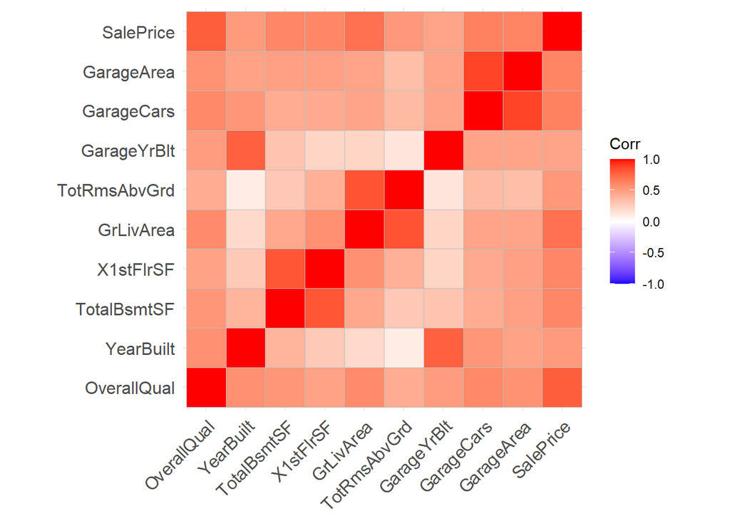

```r
col.to.investigate <- colnames(quantitative.variables)[apply(correlation,
    2, secondHighest) > 0.7]

correlation.plot.data <- quantitative.variables %>% dplyr::select(col.to.investigate)

ggcorrplot(cor(correlation.plot.data))
```

So, from looking at the plot, the following predictors are highly correlated:

- GarageCars and GarageArea
- GarageYrBlt and YearBlt
- TotalBsmtSF and X1stFlrSF
- TotRmsAbvGrd and GrLivArea

Based on this, remove the following columns:

- GarageCars
- GarageYrBlt
- TotalBsmtSF
- GrLivArea

```r
col.to.remove <- c("GarageCars", "GarageYrBlt", "TotalBsmtSF", "GrLivArea")

train <- train %>% dplyr::select(-c(col.to.remove))
```

## 3.3 Transformations

To start, investigate the distribution of the response variable:

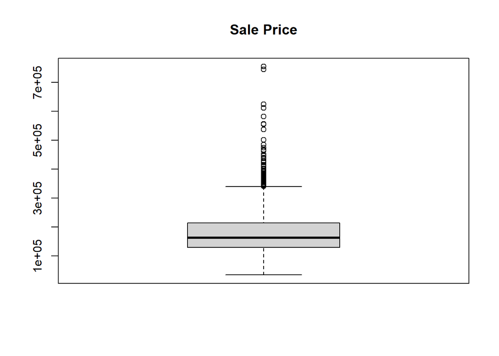

```r
boxplot(train$SalePrice, main = "Sale Price")
```

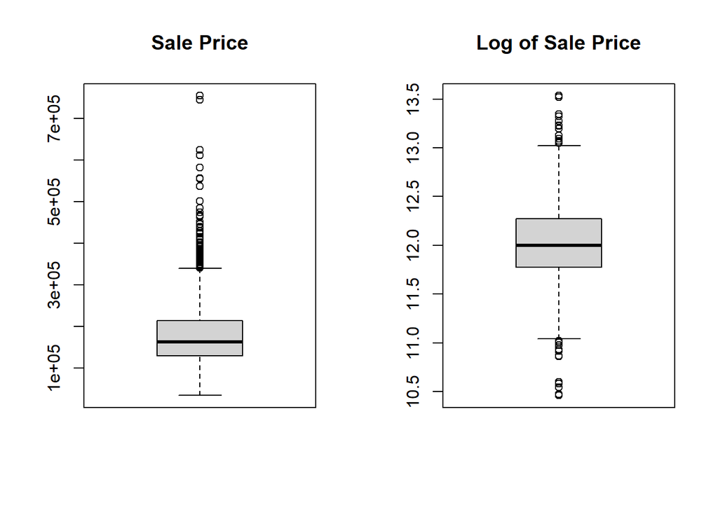

```r
par(mfrow = c(1, 2))
boxplot(train$SalePrice, main = "Sale Price")

boxplot(log(train$SalePrice), main = "Log of Sale Price")
```

```r
train$SalePrice <- log(train$SalePrice)
```

Next, investigate the relationships between the predictors and the transformed response, to see if any need to be transformed. The goal is to get a linear relationship between each predictor and the transformed response:

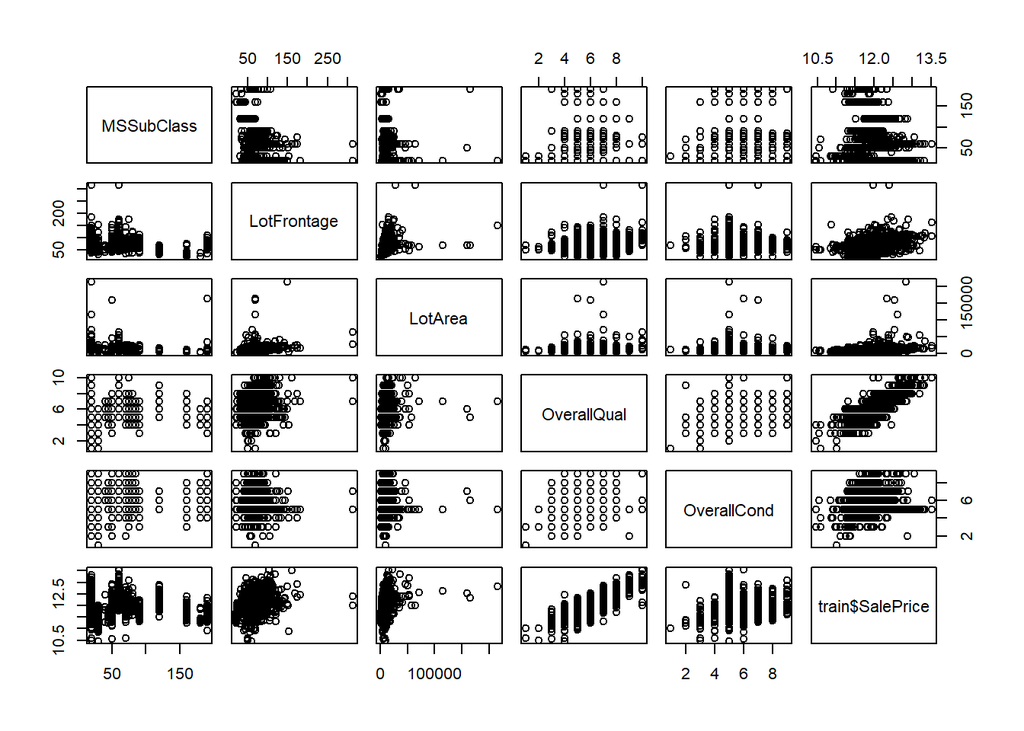

```r
pairs(cbind(quantitative.variables[, 1:5], train$SalePrice))
```

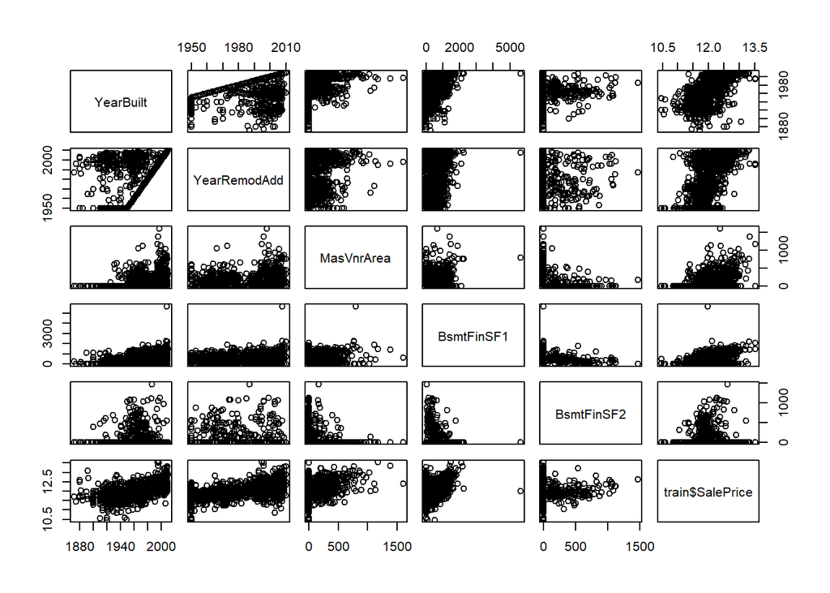

```r
pairs(cbind(quantitative.variables[, 6:10], train$SalePrice))
```

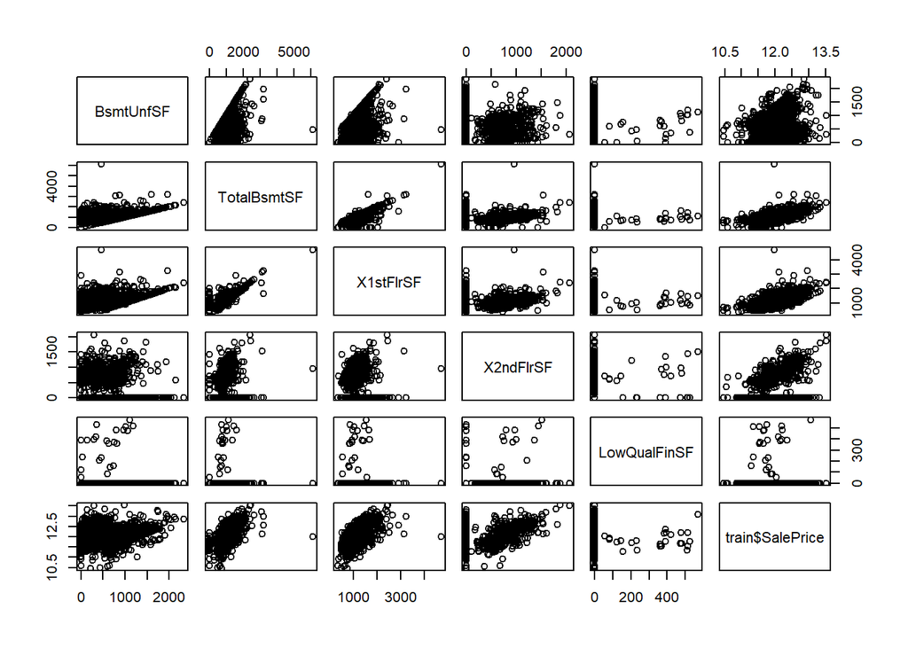

```r
pairs(cbind(quantitative.variables[, 11:15], train$SalePrice))
```

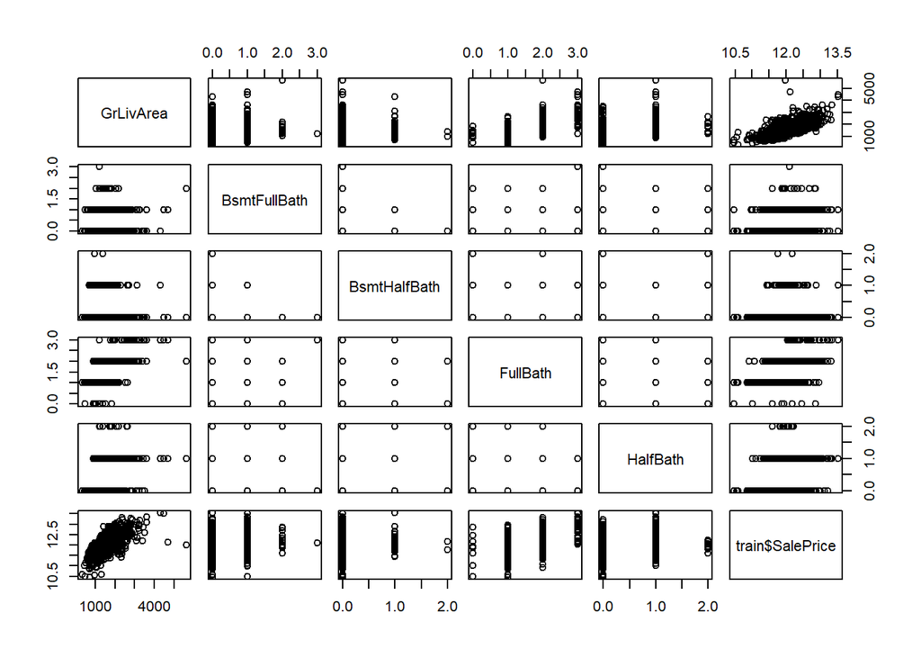

```r
pairs(cbind(quantitative.variables[, 16:20], train$SalePrice))
```

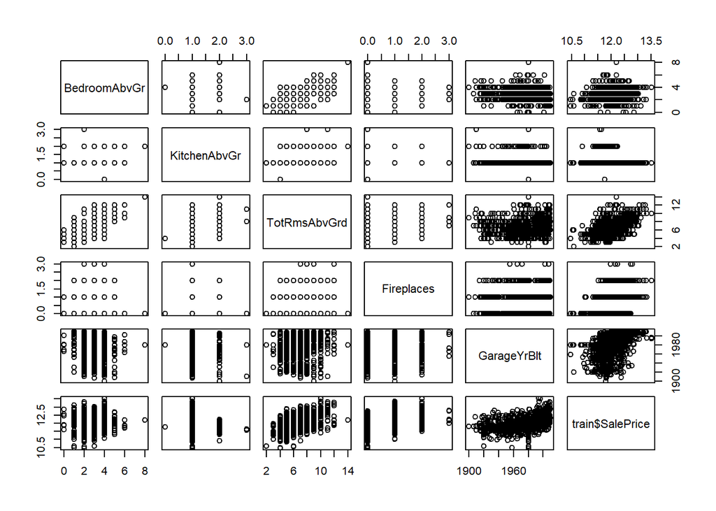

```r
pairs(cbind(quantitative.variables[, 21:25], train$SalePrice))
```

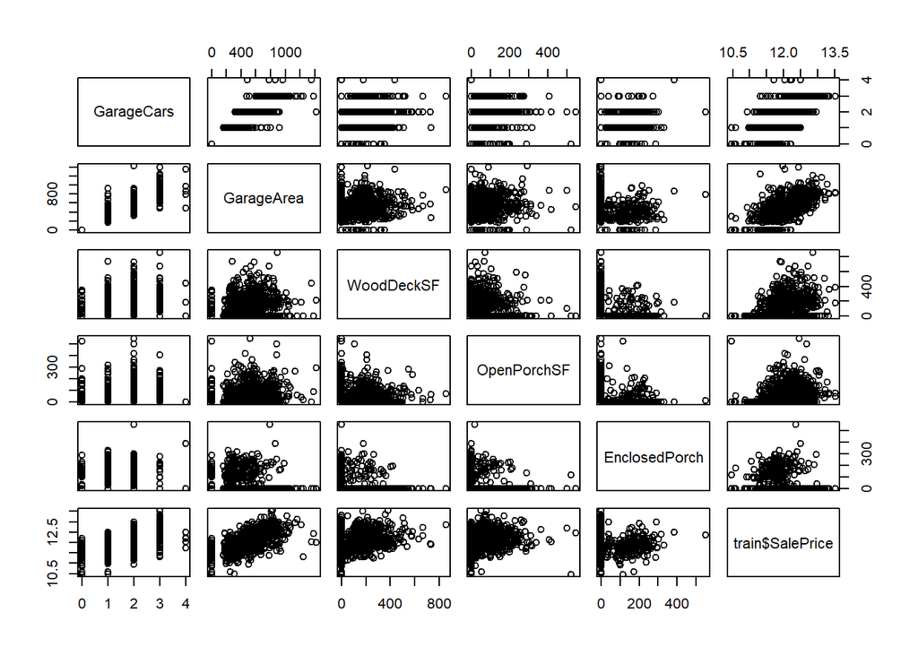

```r
pairs(cbind(quantitative.variables[, 26:30], train$SalePrice))
```

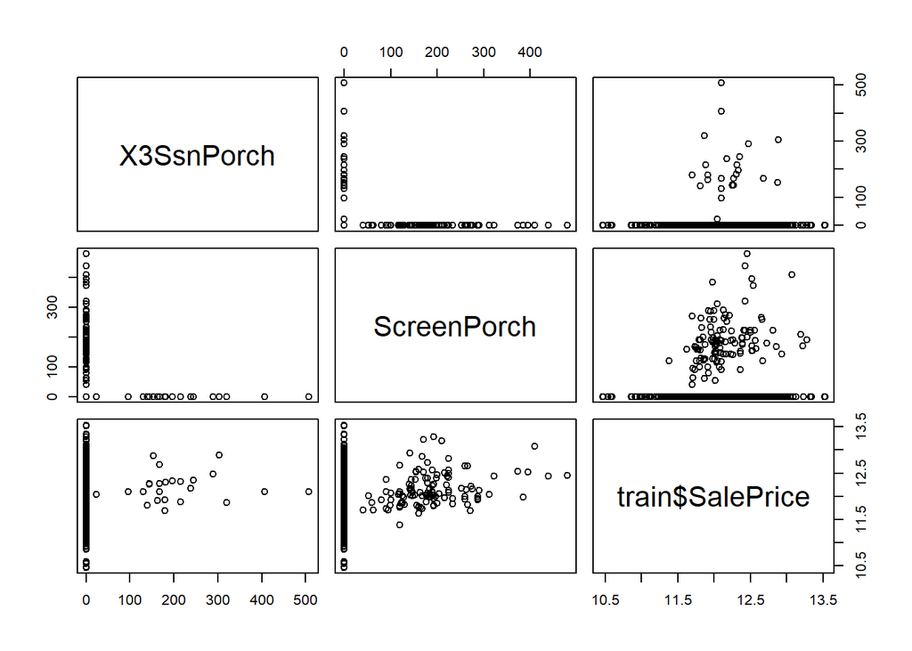

```r
pairs(cbind(quantitative.variables[, 31:32], train$SalePrice))
```

Some transformations that need to be undertaken include:

- LotArea
- LotFrontage

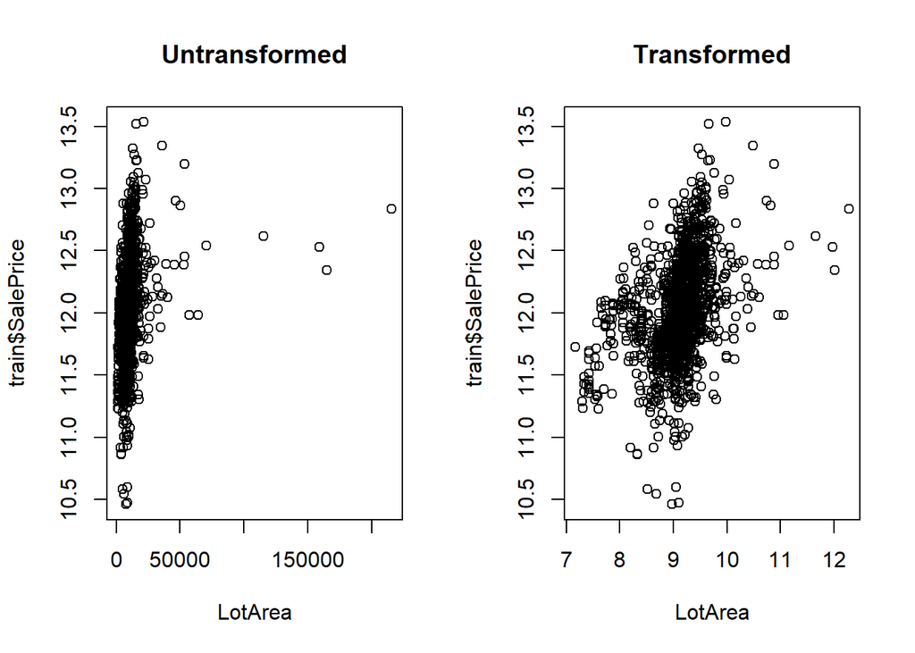

```r
par(mfrow = c(1, 2))
plot(train$SalePrice ~ train$LotArea, xlab = "LotArea", main = "Untransformed")
plot(train$SalePrice ~ log(train$LotArea), xlab = "LotArea", main = "Transformed")
```

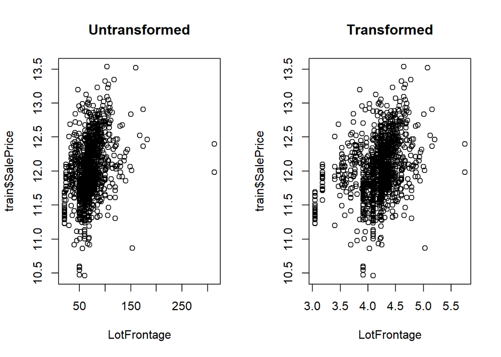

```r
par(mfrow = c(1, 2))
plot(train$SalePrice ~ train$LotFrontage, xlab = "LotFrontage", main = "Untransformed")
plot(train$SalePrice ~ log(train$LotFrontage), xlab = "LotFrontage", main = "Transformed")
```

Apply these transformations to the predictor variables:

```r
train$LotArea <- log(train$LotArea)
train$LotFrontage <- log(train$LotFrontage)
```

Do the same modifications to the test set:

```r
tmp.test <- test %>% dplyr::select(-c(col.to.remove))
### Impute any missing values with the median of the training set set
for (i in 1:ncol(tmp.test)) {
    tmp.test[is.na(tmp.test[, i]), i] <- median(train[, i], na.rm = TRUE)
}

tmp.test$LotArea <- log(tmp.test$LotArea)
tmp.test$LotFrontage <- log(tmp.test$LotFrontage)
```

Next, it is evident that only 7 houses have a pool area not equal to 0, and 24 houses have a 3 season porch.

```r
sum(train$PoolArea != 0)
```

```
## [1] 7
```

```r
sum(train$X3SsnPorch != 0)
```

```
## [1] 24
```

Remove these columns:

```r
train <- train %>% dplyr::select(-c(PoolArea, X3SsnPorch))
tmp.test <- tmp.test %>% dplyr::select(-c(PoolArea, X3SsnPorch))
```

Here, engineer a new variable to be the total square footage of the house:

```r
train$totalsf <- train$X2ndFlrSF + train$X1stFlrSF
tmp.test$totalsf <- tmp.test$X2ndFlrSF + tmp.test$X1stFlrSF
```

Split the training set into train.x for the predictor variables and train.y for the response variable.

```r
train <- train
train.x <- train %>% dplyr::select(-c(SalePrice))
train.y <- train$SalePrice
test <- tmp.test

rownames(train) <- 1:nrow(train)
```

## 3.4 A note on RMSE

In order to compare my estimated cross-validation RMSE values to the Kaggle true errors of the test set, I will use the following formula to calculate cross-validation error:

$$\sqrt{\sum_{i=1}^{N} \frac{(log(Predicted_i) - log(Actual_i))^2}{N}}$$

# 4 KNN Method

## 4.1 Scale the Data

Initialize a data frame to populate with our summary information:

```r
summary.knn <- data.frame(k = rep(NA, 50), r2 = rep(NA, 50), PRESS = rep(NA,
    50), rmse = rep(NA, 50))
```

Scale the data:

```r
train.x.scaled <- as.data.frame(scale(train.x))
### Scale the test data using the mean and sd of the training data
tmp.mean <- apply(train.x, 2, mean)
tmp.sd <- apply(train.x, 2, sd)
test.scaled <- test
for (i in 1:ncol(test)) {
    test.scaled[, i] <- (test.scaled[, i] - tmp.mean[i])/tmp.sd[i]
}
test.scaled <- as.data.frame(test.scaled)
```

## 4.2 Build the KNN Model

When no test is supplied to knn.reg, LOOCV is performed!

```r
for (i in 1:50) {
    tmp.knn <- knn.reg(train.x.scaled, test = NULL, train.y, k = i)
    pred.knn <- tmp.knn$pred
    actual <- train.y
    rmse.knn <- sqrt(mean(((actual) - (pred.knn))^2))
    summary.knn[i, 1] <- tmp.knn$k
    summary.knn[i, 2] <- tmp.knn$R2Pred
    summary.knn[i, 3] <- tmp.knn$PRESS
    summary.knn[i, 4] <- rmse.knn
}

cv.rmse.knn <- min(summary.knn$rmse)
```

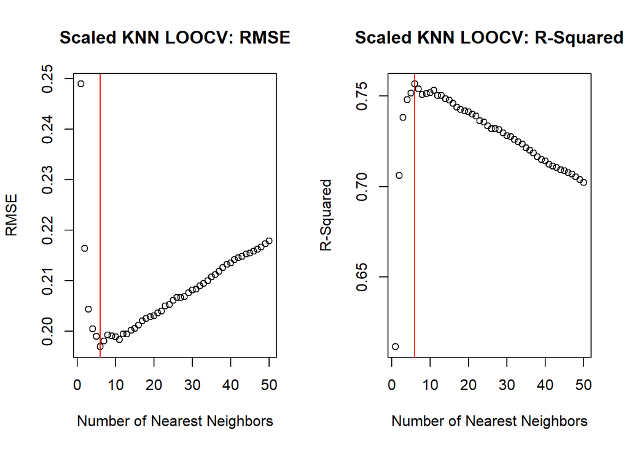

```r
par(mfrow = c(1, 2))
plot(summary.knn$rmse ~ summary.knn$k, xlab = "Number of Nearest Neighbors",
    ylab = "RMSE", main = "Scaled KNN LOOCV: RMSE")
abline(v = which(summary.knn$rmse == min(summary.knn$rmse)), col = "red")
plot(summary.knn$r2 ~ summary.knn$k, xlab = "Number of Nearest Neighbors",
    ylab = "R-Squared", main = "Scaled KNN LOOCV: R-Squared")
abline(v = which(summary.knn$r2 == max(summary.knn$r2)), col = "red")
```

A tuning parameter of 6 minimizes the error and maximizes R-squared.

Here, use the optimal k of 6.

## 4.3 Make Predictions

Now, perform predictions on the test data with k = 6.

```r
knn.model <- knn.reg(train = train.x.scaled, test = test.scaled, y = train.y,
    k = 6)

knn.pred <- exp(knn.model$pred)
```

# 5 Linear Regression

## 5.1 Fit a Model - All Predictors

Start with fitting a model with all predictor variables and the transformed response.

```r
train.final <- train
lm.model.1 <- lm(SalePrice ~ ., data = train.final)
lm.summary.1 <- summary(lm.model.1)
lm.summary.1$adj.r.squared
```

```
## [1] 0.9332291
```

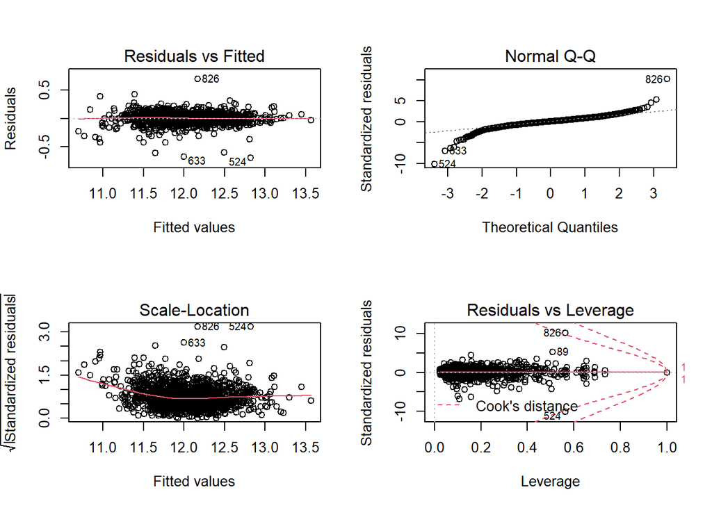

```r
par(mfrow = c(2, 2))
plot(lm.model.1)
```

Here, we have a really big red flag!! For instances 121, 186, 251, 326, 333, 376, 399, 584, 596, 667, 811, 945, 1004, 1012, 1188, 1231, 1271, 1276, 1299, 1322, 1371, and 1387, I am getting a “not plotting observations with leverage one error”.

Upon investigating this, this error will occur if groups have only one member. Look into this:

```r
temp.matrix <- matrix(data = NA, nrow = 400, ncol = 3)
colnames(temp.matrix) <- c("Predictor", "Absent", "Present")
count <- 1
for (i in 1:ncol(train.final)) {
    if (length(unique(train.final[, i])) == 2) {
        temp.matrix[count, 1] <- colnames(train.final)[i]
        temp.matrix[count, 2] <- as.integer(sum(train.final[, i] == 0))
        temp.matrix[count, 3] <- as.integer(sum(train.final[, i] == 1))
        count <- count + 1
    }
}

temp.matrix <- na.omit(as.data.frame(temp.matrix))

(temp.matrix %>% dplyr::filter(as.integer(Absent) < 4 | as.integer(Present) <
    4))
```

```
##              Predictor Absent Present
## 1      UtilitiesAllPub      1    1459
## 2      UtilitiesNoSeWa   1459       1
## 3  NeighborhoodBlueste   1458       2
## 4       Condition1RRNe   1458       2
## 5     Condition2Artery   1458       2
## 6       Condition2PosA   1459       1
## 7       Condition2PosN   1458       2
## 8       Condition2RRAe   1459       1
## 9       Condition2RRAn   1459       1
## 10      Condition2RRNn   1458       2
## 11       RoofStyleShed   1458       2
## 12     RoofMatlClyTile   1459       1
## 13     RoofMatlMembran   1459       1
## 14       RoofMatlMetal   1459       1
```

[output cut: 30 more lines]

```r
col.to.exclude <- (temp.matrix %>% dplyr::filter(as.integer(Absent) < 4 |
    as.integer(Present) < 4))$Predictor
```

So, it looks like many predictors only have one, two, or three instance in some columns. Remove these columns. These predictors will not help us build any model moving forward.

```r
train.final <- train.final %>% dplyr::select(-c(col.to.exclude))

test.final <- test %>% dplyr::select(-c(col.to.exclude))
```

## 5.2 Model 2

Now, fit the model again, with these predictors removed.

```r
lm.model.2 <- lm(SalePrice ~ ., data = train.final)
lm.summary.2 <- summary(lm.model.2)
lm.summary.2$adj.r.squared
```

```
## [1] 0.9156762
```

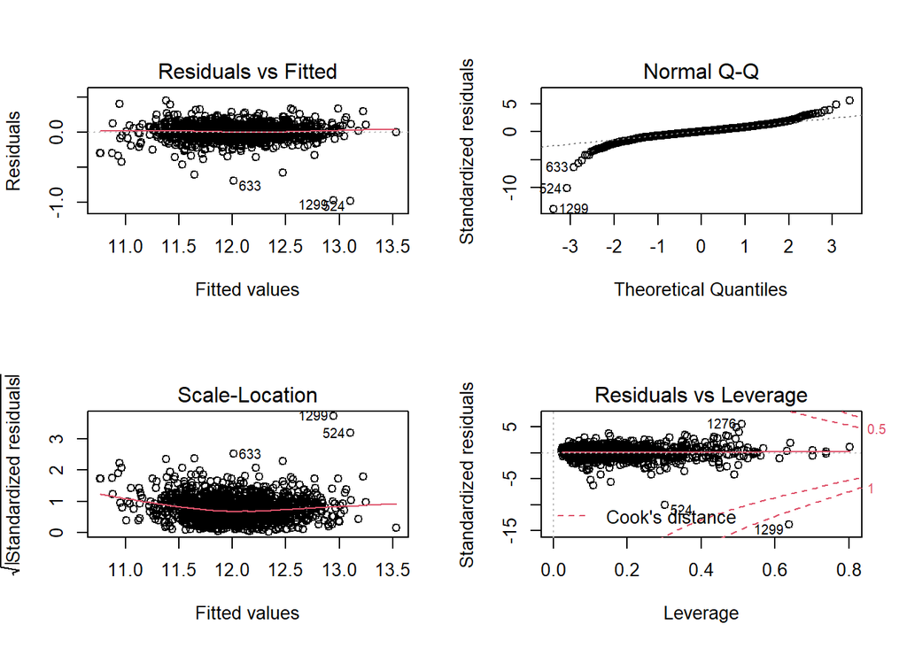

```r
par(mfrow = c(2, 2))
plot(lm.model.2)
```

This looks a lot better! But, for some reason 4 instances still have a leverage of 1!

Remove these, and refit the model:

```r
train.final <- train.final[-c(326, 333, 667, 949), ]
```

## 5.3 Model 3

Now, fit the model again, with these predictors removed.

```r
lm.model.3 <- lm(SalePrice ~ ., data = train.final)
lm.summary.3 <- summary(lm.model.3)
lm.summary.3$adj.r.squared
```

```
## [1] 0.9156199
```

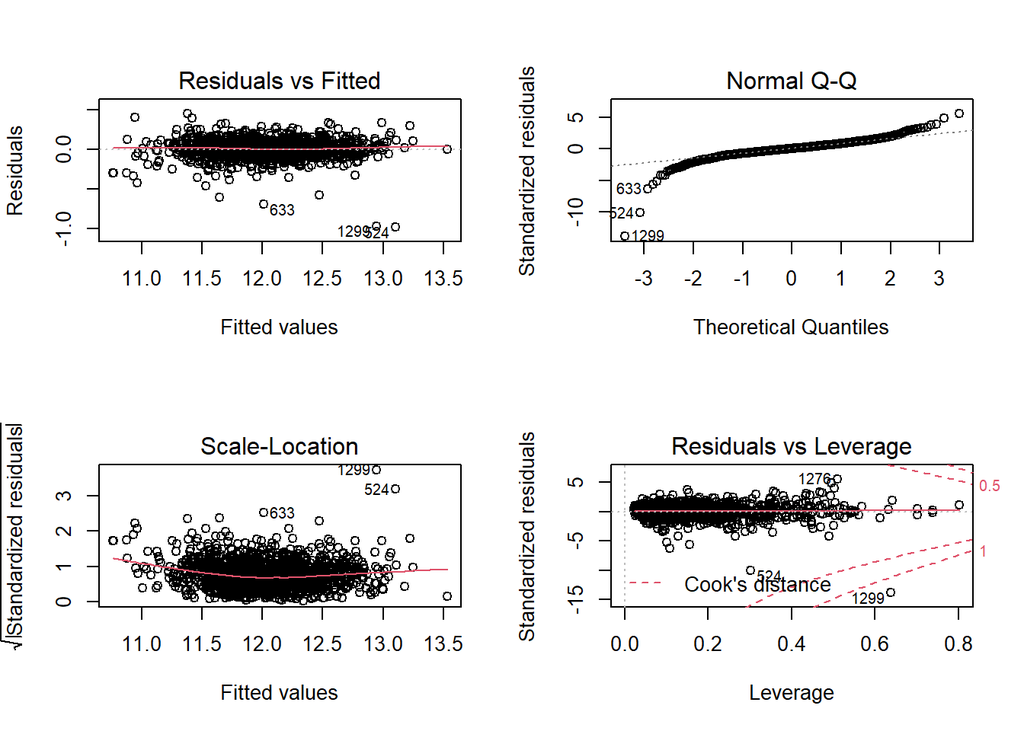

```r
par(mfrow = c(2, 2))
plot(lm.model.3)
```

Here, there are a few points that need to be removed. Namely, 524 and 1299 exceed 3 standard deviations in the standardized residual plot. And, 1299 exceeds 1 Cook’s distance in the Residuals vs Leverage plot, further justifying its removal.

## 5.4 Model 4

```r
train.final <- train.final[rownames(train.final) != "524", ]
train.final <- train.final[rownames(train.final) != "1299", ]

lm.model.4 <- lm(SalePrice ~ ., data = train.final)
lm.summary.4 <- summary(lm.model.4)
lm.summary.4$adj.r.squared
```

```
## [1] 0.9382257
```

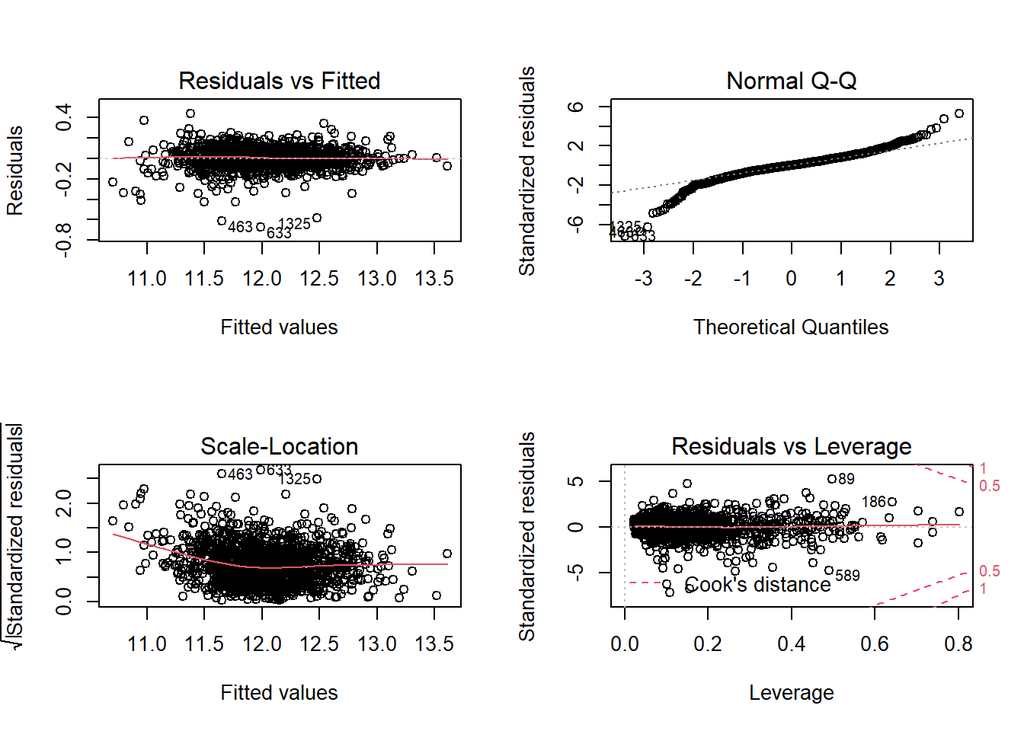

```r
par(mfrow = c(2, 2))
plot(lm.model.4)
```

Here, the residual versus fitted plot looks good! It looks like there is equal variance, there is no obvious patterns, and the red, dashed line is essentially at zero.

Similarly, the scale-location plot looks acceptable. There is a slight curve, though I think this is okay.

The one major problem is the normal Q-Q plot. There is obvious deviation in the lower tail. However, the adjusted R squared is improved, and there are no obvious transformations that will improve the model.

## 5.5 Interpret Coefficients

Next, interpret some coefficients:

```r
lm.model.4$coefficients
```

```
##            (Intercept)             MSSubClass      `MSZoningC (all)`
##           8.523569e+00           5.048769e-05          -3.888419e-01
##             MSZoningFV             MSZoningRH             MSZoningRL
##           5.869751e-02           5.339812e-02           2.542937e-02
##             MSZoningRM            LotFrontage                LotArea
##                     NA           2.473055e-02           9.422585e-02
##             StreetGrvl             StreetPave              AlleyGrvl
##          -9.892097e-02                     NA          -3.110309e-02
##          AlleynoAccess              AlleyPave            LotShapeIR1
##          -3.720992e-02                     NA          -8.637961e-03
##            LotShapeIR2            LotShapeIR3            LotShapeReg
##           7.119068e-03           1.957998e-02                     NA
##         LandContourBnk         LandContourHLS         LandContourLow
##          -6.559871e-03           8.157254e-03          -4.019836e-02
##         LandContourLvl        LotConfigCorner       LotConfigCulDSac
##                     NA           1.070192e-02           3.496991e-02
##           LotConfigFR2           LotConfigFR3        LotConfigInside
##          -2.260701e-02          -6.635715e-02                     NA
##           LandSlopeGtl           LandSlopeMod           LandSlopeSev
##           7.475164e-02           9.675322e-02                     NA
##    NeighborhoodBlmngtn     NeighborhoodBrDale    NeighborhoodBrkSide
##           5.632902e-03          -4.791488e-02          -1.151198e-02
##    NeighborhoodClearCr    NeighborhoodCollgCr    NeighborhoodCrawfor
##          -2.456316e-02          -6.610811e-02           7.139441e-02
##    NeighborhoodEdwards    NeighborhoodGilbert     NeighborhoodIDOTRR
##          -1.087723e-01          -6.066087e-02          -5.665454e-02
##    NeighborhoodMeadowV    NeighborhoodMitchel      NeighborhoodNAmes
##          -1.515306e-01          -9.751593e-02          -7.356089e-02
##    NeighborhoodNoRidge    NeighborhoodNPkVill    NeighborhoodNridgHt
##          -2.440800e-02           2.534406e-02           4.054810e-04
##     NeighborhoodNWAmes    NeighborhoodOldTown     NeighborhoodSawyer
##          -8.704484e-02          -7.204104e-02          -6.663326e-02
##    NeighborhoodSawyerW    NeighborhoodSomerst    NeighborhoodStoneBr
##          -6.239231e-02          -3.137288e-02           7.978902e-02
##      NeighborhoodSWISU     NeighborhoodTimber    NeighborhoodVeenker
##          -2.773543e-02          -5.293877e-02          -2.140833e-02
##       Condition1Artery        Condition1Feedr         Condition1Norm
##          -3.610019e-02          -4.484751e-03           4.078038e-02
##         Condition1PosA         Condition1PosN         Condition1RRAe
##          -3.323756e-02           3.106071e-02          -9.080995e-02
```

[output cut: 115 more lines]

```
##          -3.570711e-02          -1.032429e-02          -1.891136e-02
##           FencenoFence        MiscFeatureShed                MiscVal
##                     NA           1.321739e-01           4.956530e-06
##                 MoSold                 YrSold            SaleTypeCOD
##           1.214851e-04          -2.160420e-03          -7.221018e-02
##          SaleTypeConLD          SaleTypeConLI          SaleTypeConLw
##           5.774774e-02          -1.167302e-01          -5.464166e-02
##            SaleTypeCWD            SaleTypeNew             SaleTypeWD
##          -1.327359e-02           6.352780e-02          -8.675884e-02
##   SaleConditionAbnorml   SaleConditionAdjLand    SaleConditionAlloca
##           4.001349e-02           1.973473e-01           1.202071e-01
##    SaleConditionFamily    SaleConditionNormal   SaleConditionPartial
##           5.016034e-02           1.091989e-01                     NA
##                totalsf
##                     NA
```

Note that some predictors are NA, because there are linearly dependent on other predictors. For example, totalsf can be expressed as the sum of the square foot of the first and second levels, which is why it’s not included in the linear model.

## 5.6 Make Predictions

Next, make predictions on the test set, using all variables.

Remember, these predictions are of the log of the sale price! So, convert from the log of the sale price to the actual sale price:

```r
lm.pred.tmp <- predict(lm.model.4, test.final)
lm.pred <- exp(lm.pred.tmp)
```

Here, perform ten-fold cross validation to get an estimate of the test error we expect:

```r
fold.index <- cut(sample(1:nrow(train.final)), breaks = 10, labels = FALSE)
trainLinear <- train.final
trainLinear$Fold <- fold.index

MSE.list <- c()
for (i in 1:10) {
    temp.train <- trainLinear[trainLinear$Fold != i, ] %>% dplyr::select(-c(Fold))

    temp.test <- trainLinear[trainLinear$Fold == i, ] %>% dplyr::select(-c(Fold,
        SalePrice))

    actual <- trainLinear[trainLinear$Fold == i, ] %>% dplyr::select(SalePrice)

    temp.pred <- predict(lm(SalePrice ~ ., data = temp.train), temp.test)

    MSE.list[i] <- sqrt(mean(((temp.pred) - (actual[, 1]))^2))
}
cv.rmse.linear <- mean(MSE.list)
```

```r
train.rm.out <- train[-c(524, 1299), ]
```

# 6 Subset Selection

Certainly, this linear model can be improved by performing subset selection.

Because of the size of the data, I will not conduct an exhaustive search, though I am confident that the Forward and Backyard subset selection will be sufficient.

## 6.1 Forward Stepwise

```r
subset.selection.for <- regsubsets(SalePrice ~ ., data = train.final, nvmax = 150,
    method = "forward")
```

```
## Reordering variables and trying again:
```

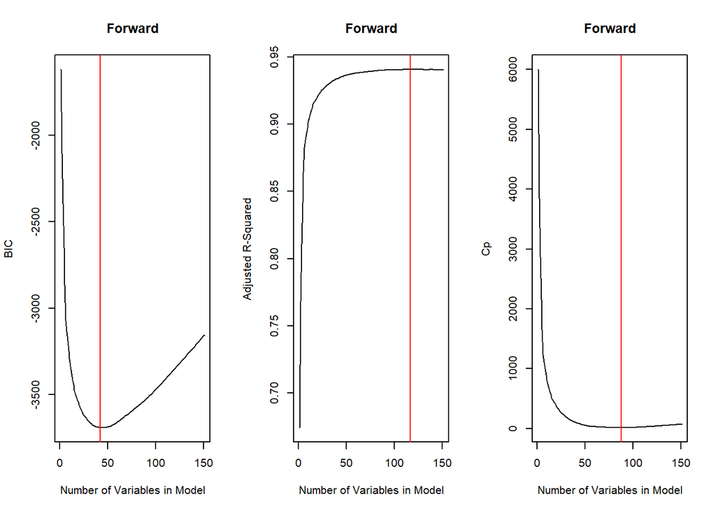

```r
summary.subset.for <- summary(subset.selection.for)
df <- data.frame(sub = 1:length(summary.subset.for$bic), bic = summary.subset.for$bic,
    adjr2 = summary.subset.for$adjr2, cp = summary.subset.for$cp)
par(mfrow = c(1, 3))
plot(df$bic ~ df$sub, type = "l", xlab = "Number of Variables in Model",
    main = "Forward", ylab = "BIC")
abline(v = which(df$bic == min(df$bic)), col = "red")
plot(df$adjr2 ~ df$sub, type = "l", main = "Forward", xlab = "Number of Variables in Model",
    ylab = "Adjusted R-Squared")
abline(v = which(df$adjr2 == max(df$adjr2)), col = "red")
plot(df$cp ~ df$sub, type = "l", main = "Forward", xlab = "Number of Variables in Model",
    ylab = "Cp")
abline(v = which(df$cp == min(df$cp)), col = "red")
```

## 6.2 Backward Stepwise

```r
subset.selection.back <- regsubsets(SalePrice ~ ., data = train.final,
    nvmax = 300, method = "backward")
```

```
## Reordering variables and trying again:
```

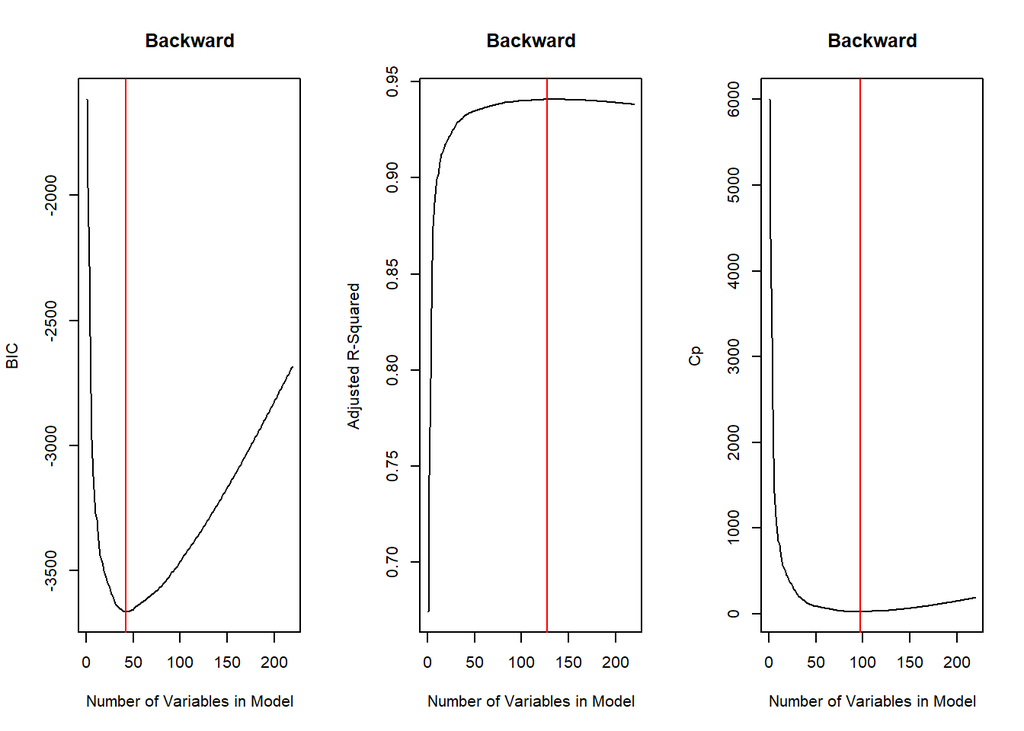

```r
summary.subset.back <- summary(subset.selection.back)
df <- data.frame(sub = 1:length(summary.subset.back$bic), bic = summary.subset.back$bic,
    adjr2 = summary.subset.back$adjr2, cp = summary.subset.back$cp)
par(mfrow = c(1, 3))
plot(df$bic ~ df$sub, type = "l", xlab = "Number of Variables in Model",
    main = "Backward", ylab = "BIC")
abline(v = which(df$bic == min(df$bic)), col = "red")
plot(df$adjr2 ~ df$sub, type = "l", main = "Backward", xlab = "Number of Variables in Model",
    ylab = "Adjusted R-Squared")
abline(v = which(df$adjr2 == max(df$adjr2)), col = "red")
plot(df$cp ~ df$sub, type = "l", main = "Backward", xlab = "Number of Variables in Model",
    ylab = "Cp")
abline(v = which(df$cp == min(df$cp)), col = "red")
```

## 6.3 Cross-Validation

Because forward and backward subset selection methods gave very similar results, I will just use the forward subset selection method in cross-validation.

And, because of the large number of predictors, I will use 5-fold cross validation instead of 10-fold cross validation.

```r
predict.regsubsets = function(object, newdata, id, ...) {
    form = as.formula(object$call[[2]])  # Extract the formula used when we called regsubsets()
    mat = model.matrix(form, newdata)  # Build the model matrix
    coefi = coef(object, id = id)  # Extract the coefficiants of the ith model
    xvars = names(coefi)  # Pull out the names of the predictors used in the ith model
    mat[, xvars] %*% coefi  # Make predictions using matrix multiplication
}
```

```r
fold.index <- cut(sample(1:nrow(train.final)), breaks = 5, labels = FALSE)
train.final$fold <- fold.index

df <- data.frame(i = rep(NA, 100), mean_error = rep(NA, 100))
```

```r
cv.error.best.fit <- rep(0, 100)
for (i in 1:100) {
    # try different numbers of variables
    error <- rep(0, 100)
    for (k in 1:5) {
        tmp.train <- train.final[fold.index != k, ]
        tmp.test <- train.final[fold.index == k, ]
        true.y <- tmp.test[, "SalePrice"]
        best.fit <- regsubsets(SalePrice ~ ., data = tmp.train, nvmax = 100,
            method = "forward")
        pred <- predict(best.fit, tmp.test, id = i)
        error[k] <- sqrt((mean((pred - true.y)^2)))
    }
    cv.error.best.fit[i] <- mean(error)
}
```

[output not shown]

[output cut: 445 more lines]

[output not shown]

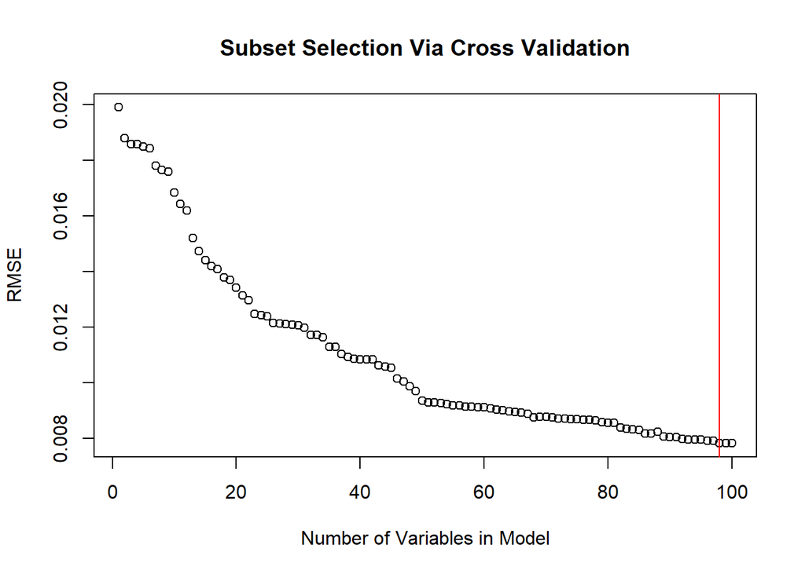

```r
df <- as.data.frame(cbind(error = cv.error.best.fit, i = 1:100))

plot(df$error ~ df$i, xlab = "Number of Variables in Model", ylab = "RMSE",
    main = "Subset Selection Via Cross Validation")
abline(v = which(df$error == min(df$error)), col = "red")
```

```r
cv.rmse.bestsubset <- min(df$error)
train.final <- train.final %>% dplyr::select(-c(fold))
```

```r
df$i[df$error == min(df$error)]
```

```
## [1] 98
```

## 6.4 Select a Model

The criterion that I considered when selecting my model were adjusted R-squared, BIC, Cp, and cross-validation. Both methods yield a different conclusion for the number of variables to include in the model:

Ideal Number of Variables to Include in Model, For a Range of Methods and Criteria

[output not shown]

The number of predictors to include in the model differs both by method and metric.

Ultimately, the goal is to minimize RMSE, because our goal is to make accurate predictions.

## 6.5 Make Predictions

```r
regfit.full <- regsubsets(SalePrice ~ ., data = train.rm.out, nvmax = 300,
    method = "forward")
```

```
## Reordering variables and trying again:
```

```r
test$SalePrice <- rep(0, nrow(test))

library(leaps)
pred.best.subset <- exp(predict.regsubsets(regfit.full, newdata = test,
    id = 96))
coef(regfit.full, 98)
```

```
##            (Intercept)      `MSZoningC (all)`            LotFrontage
##           1.079284e+01          -5.514536e-01           3.138689e-02
##                LotArea             StreetGrvl            LotShapeIR3
##           7.070816e-02           0.000000e+00          -3.257194e-03
##           LandSlopeGtl    NeighborhoodBlmngtn    NeighborhoodBlueste
##          -1.977014e-02           4.503095e-02           6.445709e-02
##    NeighborhoodClearCr    NeighborhoodEdwards    NeighborhoodGilbert
##          -1.049023e-02          -1.208817e-01          -3.510644e-02
##    NeighborhoodMitchel      NeighborhoodNAmes    NeighborhoodNPkVill
##          -6.654011e-02          -7.645519e-02           3.795570e-02
##    NeighborhoodNridgHt     NeighborhoodSawyer    NeighborhoodSawyerW
##           1.235132e-01          -8.085355e-02          -5.158096e-02
##    NeighborhoodStoneBr      NeighborhoodSWISU     NeighborhoodTimber
##           1.425620e-01          -8.765012e-02           9.875144e-03
##         Condition1PosN         Condition1RRAe         Condition1RRAn
##          -2.161673e-02          -8.478542e-02          -4.043218e-02
##       Condition2Artery        Condition2Feedr         Condition2PosA
##          -2.647085e-01           6.228406e-02           2.756028e-01
##         Condition2RRAe         Condition2RRAn       HouseStyle1Story
##          -5.811569e-02          -1.385754e-01          -2.346195e-02
##       HouseStyle2.5Fin       HouseStyle2Story       RoofStyleMansard
##          -5.475702e-03           1.101348e-02           2.428971e-02
##      `RoofMatlTar&Grv`        RoofMatlWdShake     Exterior1stAsbShng
##           4.220019e-03          -3.782971e-02          -5.445989e-02
##     Exterior1stAsphShn       Exterior1stStone     Exterior2ndCmentBd
##           9.820969e-02          -2.066177e-01           4.074648e-02
##     Exterior2ndHdBoard       Exterior2ndOther      MasVnrTypeBrkFace
##          -1.776613e-02          -7.379553e-02          -9.343812e-03
##             MasVnrArea            ExterQualGd        FoundationPConc
##           9.074896e-05           5.975214e-02           1.065113e-01
##             BsmtCondPo             BsmtFinSF1        BsmtFinType2GLQ
##          -2.766978e-01           1.218618e-04           5.638702e-02
## BsmtFinType2noBasement        BsmtFinType2Rec             BsmtFinSF2
##          -8.554777e-02          -2.244007e-02           7.370397e-05
##            CentralAirN          ElectricalMix              X2ndFlrSF
##          -1.375645e-01           1.071860e-02          -1.330912e-04
##               HalfBath           KitchenAbvGr         FunctionalMaj2
##           1.730628e-02          -1.049779e-01          -3.019821e-01
##         FunctionalMin1          FunctionalSev             Fireplaces
##          -8.245693e-02          -4.980476e-01           1.720289e-02
```

[output cut: 11 more lines]

```
##          -4.109838e-03           1.303368e-03           1.121427e-01
##            SaleTypeOth    SaleConditionNormal             MSZoningRM
##          -4.568963e-02           3.769580e-02          -1.108063e-01
##             StreetPave        LotConfigInside           LandSlopeSev
##           8.234599e-02          -1.012000e-02          -1.042114e-01
##         Condition2RRNn        RoofMatlClyTile        RoofMatlWdShngl
##           8.665848e-04           0.000000e+00           1.564724e-01
##      Exterior2ndCBlock   `Exterior2ndWd Shng`            ExterCondTA
##          -4.316256e-01          -2.390087e-02           1.403288e-02
##     BsmtCondnoBasement            HeatingWall     GarageTypenoGarage
##          -3.182732e-02           7.464806e-02          -4.459014e-02
##     GarageQualnoGarage           GarageQualTA           PoolQCnoPool
##           0.000000e+00           7.409656e-03          -2.104832e-01
##           FencenoFence             SaleTypeWD                totalsf
##           3.150818e-03          -6.868675e-02           3.939360e-04
```

## 6.6 Interpret Coefficients

Here, interpret the coefficients of the model selected through best-subset:

```r
fold.index <- cut(sample(1:nrow(train.final)), breaks = 10, labels = FALSE)
trainCV <- train.final
trainCV$Fold <- fold.index

MSE.list <- c()
for (i in 1:10) {
    temp.train <- trainCV[trainCV$Fold == i, ]
    temp.test <- trainCV[trainCV$Fold != i, ]

    temp.train <- temp.train %>% dplyr::select(-c(Fold))
    actual <- temp.test$SalePrice

    temp.test <- temp.test %>% dplyr::select(-c(Fold))

    model <- regsubsets(SalePrice ~ ., data = temp.train, nvmax = 300,
        method = "forward")

    temp.pred <- (predict.regsubsets(model, newdata = temp.test, id = 98))

    MSE.list[i] <- sqrt(mean((actual - temp.pred)^2))
}
```

```
## Reordering variables and trying again:
## Reordering variables and trying again:
## Reordering variables and trying again:
## Reordering variables and trying again:
## Reordering variables and trying again:
## Reordering variables and trying again:
## Reordering variables and trying again:
## Reordering variables and trying again:
## Reordering variables and trying again:
## Reordering variables and trying again:
```

```r
cv.rmse.bestsubset <- mean(MSE.list)
```

# 7 Shrinkage Methods

Finally, use both a Lasso and Ridge regression to fit the data.

## 7.1 Ridge Regression

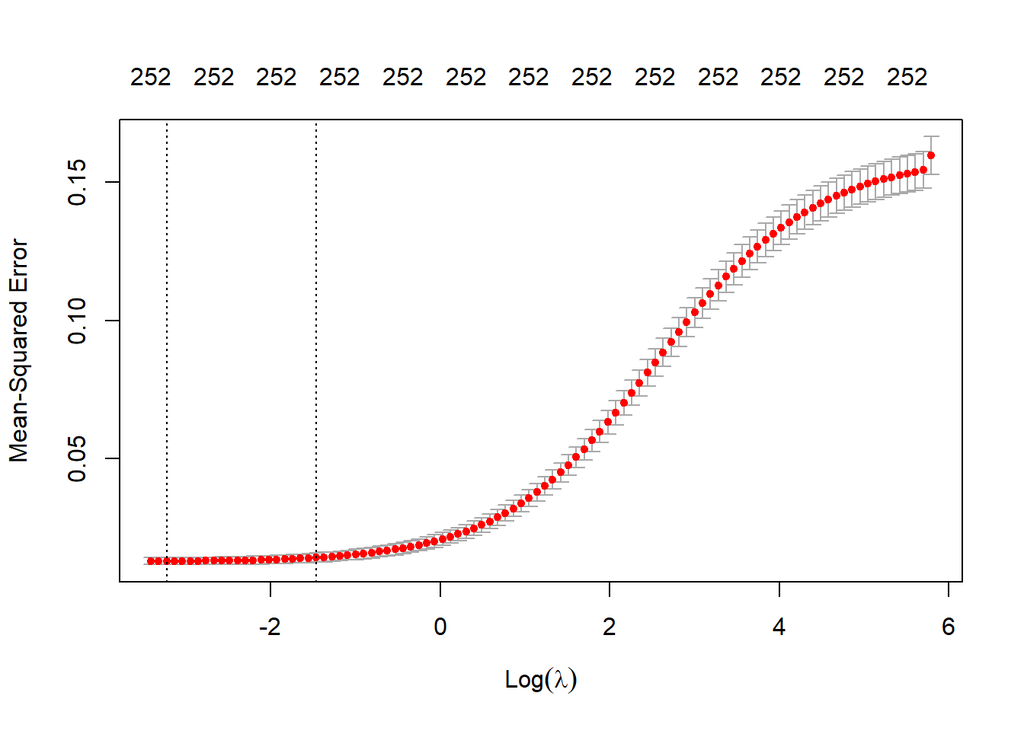

```r
train.x <- as.matrix((train.final %>% dplyr::select(-c(SalePrice))))
train.y <- train.final$SalePrice
test.x <- as.matrix(test.final)

ridge.mod <- glmnet(train.x, train.y, alpha = 0)  # 0 indicates ridge regression
cv.out <- cv.glmnet(train.x, train.y, alpha = 0, nfolds = 10)
plot(cv.out)
```

```r
bestlam <- cv.out$lambda.min
bestlam
```

```
## [1] 0.03951546
```

```r
coef(ridge.mod, s = bestlam)
```

```
## 253 x 1 sparse Matrix of class "dgCMatrix"
##                                    1
## (Intercept)             1.119734e+01
## MSSubClass             -6.126958e-05
## MSZoningC (all)        -3.648699e-01
## MSZoningFV              3.478485e-02
## MSZoningRH              3.362591e-02
## MSZoningRL              1.335571e-02
## MSZoningRM             -1.270895e-02
## LotFrontage             3.160056e-02
## LotArea                 6.672472e-02
## StreetGrvl             -4.069913e-02
## StreetPave              4.012810e-02
## AlleyGrvl              -1.276782e-02
## AlleynoAccess          -7.828104e-03
## AlleyPave               3.253802e-02
## LotShapeIR1            -3.405182e-03
## LotShapeIR2             1.239658e-02
## LotShapeIR3             1.637278e-02
## LotShapeReg             1.220200e-03
## LandContourBnk         -8.147982e-03
## LandContourHLS          1.539859e-02
## LandContourLow         -1.420231e-02
## LandContourLvl          1.616444e-03
## LotConfigCorner         3.393963e-03
## LotConfigCulDSac        3.284080e-02
## LotConfigFR2           -3.202532e-02
## LotConfigFR3           -5.349812e-02
## LotConfigInside        -6.659847e-03
## LandSlopeGtl           -1.108395e-03
## LandSlopeMod            1.063712e-02
## LandSlopeSev           -4.434842e-02
## NeighborhoodBlmngtn     3.521698e-02
## NeighborhoodBrDale     -1.438046e-02
## NeighborhoodBrkSide     1.918032e-02
## NeighborhoodClearCr     3.705191e-02
## NeighborhoodCollgCr    -6.192883e-03
## NeighborhoodCrawfor     1.074743e-01
## NeighborhoodEdwards    -5.224873e-02
## NeighborhoodGilbert    -1.226332e-02
```

[output cut: 200 more lines]

```
## YrSold                 -2.203781e-03
## SaleTypeCOD            -1.852484e-02
## SaleTypeConLD           7.857939e-02
## SaleTypeConLI          -5.637886e-02
## SaleTypeConLw           1.934102e-03
## SaleTypeCWD             4.461996e-02
## SaleTypeNew             2.649899e-02
## SaleTypeWD             -3.149395e-02
## SaleConditionAbnorml   -4.648616e-02
## SaleConditionAdjLand    4.726439e-02
## SaleConditionAlloca     2.013205e-02
## SaleConditionFamily    -4.076257e-02
## SaleConditionNormal     1.959364e-02
## SaleConditionPartial    5.678013e-03
## totalsf                 1.081563e-04
```

```r
ridge.pred <- exp(predict(ridge.mod, s = bestlam, newx = test.x))
cv.rmse.ridge <- sqrt(mean((log(exp(train.y)) - log(exp(predict(cv.out,
    train.x))))^2))
```

```r
print(cv.rmse.ridge)
```

```
## [1] 0.1058139
```

The tuning parameter for ridge regression is the minimum lambda, which was chosen through using cross validation.

## 7.2 Interpret Ridge Coefficients

Here, interpret the coefficients of the model selected through Ridge Regression:

- Holding all other variables constant, when the total square foot increases by 1 unit, the log of the expected sale price increases by 0.0001081563 dollars.
- Holding all other variables constant, when there is no garage, the log of the expected sale price decreases by 0.01323262dollars.
- Holding all other variables constant, when year built increases by 1, the log of the expected sale price increases by 0.0008491660 dollars.

## 7.3 Lasso Regression

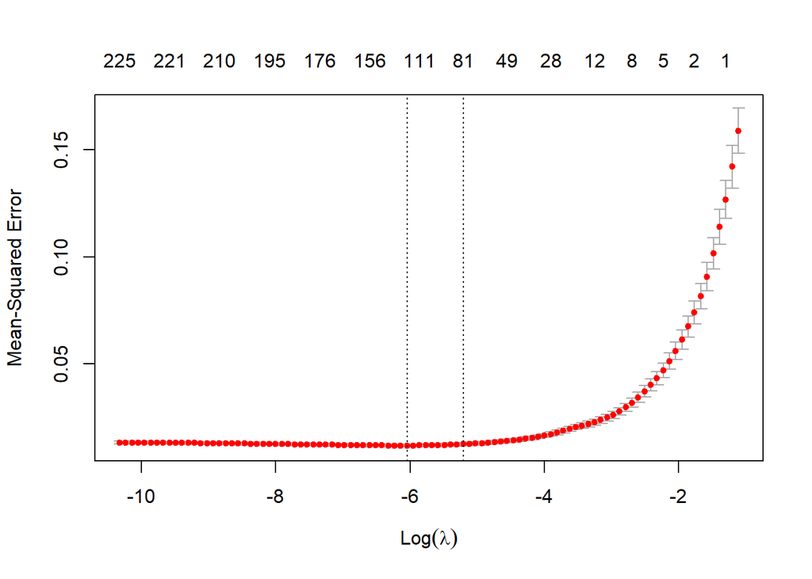

```r
lasso.mod <- glmnet(train.x, train.y, alpha = 1)  # 1 indicates lasso regression
cv.lasso.out <- cv.glmnet(train.x, train.y, alpha = 1, nfolds = 10)
pred <- predict(cv.lasso.out, train.x)
plot(cv.lasso.out)
```

```r
bestlam <- cv.lasso.out$lambda.min
bestlam
```

```
## [1] 0.002368889
```

```r
coef(lasso.mod, s = bestlam)
```

```
## 253 x 1 sparse Matrix of class "dgCMatrix"
##                                    1
## (Intercept)             6.252230e+00
## MSSubClass              .
## MSZoningC (all)        -3.613673e-01
## MSZoningFV              1.292493e-02
## MSZoningRH              .
## MSZoningRL              .
## MSZoningRM             -3.310441e-02
## LotFrontage             2.262994e-02
## LotArea                 7.641536e-02
## StreetGrvl             -4.374317e-02
## StreetPave              6.004382e-13
## AlleyGrvl               .
## AlleynoAccess           .
## AlleyPave               2.062701e-02
## LotShapeIR1             .
## LotShapeIR2             .
## LotShapeIR3             .
## LotShapeReg             .
## LandContourBnk          .
## LandContourHLS          2.869366e-03
## LandContourLow          .
## LandContourLvl          .
## LotConfigCorner         7.980185e-06
## LotConfigCulDSac        2.537301e-02
## LotConfigFR2           -9.389921e-03
## LotConfigFR3            .
## LotConfigInside         .
## LandSlopeGtl            .
## LandSlopeMod            .
## LandSlopeSev           -2.460382e-02
## NeighborhoodBlmngtn     1.835630e-02
## NeighborhoodBrDale      .
## NeighborhoodBrkSide     2.954465e-02
## NeighborhoodClearCr     2.646014e-02
## NeighborhoodCollgCr     .
## NeighborhoodCrawfor     1.083467e-01
## NeighborhoodEdwards    -3.307796e-02
## NeighborhoodGilbert     .
```

[output cut: 200 more lines]

```
## YrSold                 -6.711942e-04
## SaleTypeCOD             .
## SaleTypeConLD           5.829490e-02
## SaleTypeConLI          -2.509613e-03
## SaleTypeConLw           .
## SaleTypeCWD             1.185474e-02
## SaleTypeNew             3.721025e-02
## SaleTypeWD             -9.555628e-03
## SaleConditionAbnorml   -6.219409e-02
## SaleConditionAdjLand    .
## SaleConditionAlloca     .
## SaleConditionFamily    -4.508429e-02
## SaleConditionNormal     .
## SaleConditionPartial    .
## totalsf                 2.500755e-04
```

```r
lasso.pred <- exp(predict(lasso.mod, s = bestlam, newx = test.x))
cv.rmse.lasso <- as.vector(sqrt(cv.lasso.out$cvm[which(cv.lasso.out$lambda ==
    bestlam)]))
```

Note that the “long hand” way of finding the RSME yields the same result as taking the square root of the Mean-Squared Error at the best lambda value from the plot above. (This was also the case for the ridge regression).

```r
cv.rmse.lasso
```

```
## [1] 0.1091569
```

```r
sqrt(cv.lasso.out$cvm[cv.lasso.out$lambda == bestlam])
```

```
## [1] 0.1091569
```

Once again, the tuning parameter for lasso regression is the minimum lambda, which was chosen through using cross validation.

```r
sum(coef(lasso.mod, s = bestlam) == 0)
```

```
## [1] 128
```

```r
length(coef(lasso.mod, s = bestlam)[, 1][coef(lasso.mod, s = bestlam)[,
    1] != 0])
```

```
## [1] 125
```

```r
coef(lasso.mod, s = bestlam)[, 1][coef(lasso.mod, s = bestlam)[, 1] !=
    0]
```

```
##            (Intercept)        MSZoningC (all)             MSZoningFV
##           6.252230e+00          -3.613673e-01           1.292493e-02
##             MSZoningRM            LotFrontage                LotArea
##          -3.310441e-02           2.262994e-02           7.641536e-02
##             StreetGrvl             StreetPave              AlleyPave
##          -4.374317e-02           6.004382e-13           2.062701e-02
##         LandContourHLS        LotConfigCorner       LotConfigCulDSac
##           2.869366e-03           7.980185e-06           2.537301e-02
##           LotConfigFR2           LandSlopeSev    NeighborhoodBlmngtn
##          -9.389921e-03          -2.460382e-02           1.835630e-02
##    NeighborhoodBrkSide    NeighborhoodClearCr    NeighborhoodCrawfor
##           2.954465e-02           2.646014e-02           1.083467e-01
##    NeighborhoodEdwards    NeighborhoodMeadowV    NeighborhoodMitchel
##          -3.307796e-02          -7.143726e-02          -2.162845e-02
##    NeighborhoodNoRidge    NeighborhoodNPkVill    NeighborhoodNridgHt
##           1.871973e-02           1.452607e-02           3.744252e-02
##     NeighborhoodNWAmes    NeighborhoodOldTown    NeighborhoodSomerst
##          -7.346486e-03          -1.011582e-02           2.490671e-02
##    NeighborhoodStoneBr    NeighborhoodVeenker       Condition1Artery
##           9.693547e-02           8.580138e-03          -2.906486e-02
##         Condition1Norm         Condition1PosA         Condition1RRAe
##           3.355704e-02          -1.582793e-03          -6.800167e-02
##         BldgTypeDuplex       HouseStyle1.5Unf       HouseStyle2.5Fin
##          -1.226759e-02           2.426239e-03          -1.138815e-03
##       HouseStyle2.5Unf            OverallQual            OverallCond
##           7.573737e-03           5.279432e-02           3.408312e-02
##              YearBuilt           YearRemodAdd        RoofMatlWdShngl
##           1.739112e-03           8.560988e-04           3.524471e-02
##     Exterior1stBrkFace     Exterior1stHdBoard     Exterior1stMetalSd
##           6.020257e-02          -8.329460e-03           6.168691e-03
##     Exterior1stVinylSd     Exterior1stWd Sdng     Exterior2ndPlywood
##           8.092106e-06          -1.695150e-02          -1.164980e-03
##       MasVnrTypeBrkCmn        MasVnrTypeStone             MasVnrArea
##          -8.405495e-03           1.963444e-02           9.646254e-06
##            ExterQualEx            ExterQualTA            ExterCondFa
##           6.709415e-03          -7.486899e-03          -1.441149e-02
##            ExterCondTA        FoundationPConc         FoundationSlab
##           1.256489e-02           2.771531e-02          -1.388228e-03
##        FoundationStone             BsmtQualEx     BsmtQualnoBasement
##           4.929384e-02           3.117789e-02          -4.494896e-02
```

[output cut: 29 more lines]

```
##           1.269738e-04          -1.218043e-02           9.643023e-03
##           GarageCondFa           GarageCondPo            PavedDriveY
##          -3.149220e-02           2.455165e-03           1.441896e-02
##             WoodDeckSF            OpenPorchSF          EnclosedPorch
##           6.527794e-05           9.051493e-05           2.190812e-05
##            ScreenPorch           PoolQCnoPool              FenceGdWo
##           1.827231e-04          -1.763430e-02          -1.706613e-02
##           FencenoFence        MiscFeatureShed                 YrSold
##           1.507515e-03           4.303510e-02          -6.711942e-04
##          SaleTypeConLD          SaleTypeConLI            SaleTypeCWD
##           5.829490e-02          -2.509613e-03           1.185474e-02
##            SaleTypeNew             SaleTypeWD   SaleConditionAbnorml
##           3.721025e-02          -9.555628e-03          -6.219409e-02
##    SaleConditionFamily                totalsf
##          -4.508429e-02           2.500755e-04
```

## 7.5 Model Interpretation

The Lasso model has much better interpretation, because many predictors coefficients become 0, while in the Ridge model the coefficients are all non-zero.

It’s easy to interpret variables with a coefficient of 0, because they must not be significant predictors of sale price. But, variables that have a very small coefficient are still included in Ridge models despite likely not being significant predictors of sale price.

# 8 Regression Tree

Initially, I was running into problems building the regression tree. Ultimately, there were problems with the column names with contained certain characters (., &, 1, 2, 3, 5). So, I removed these characters from the column names in the following loop:

```r
colNames <- colnames(train.final)
for (i in 1:length(colNames)) {
    if (str_detect(colNames[i], " ") == TRUE) {
        colNames[i] <- str_replace(colNames[i], " ", "")
    }
    if (str_detect(colNames[i], ".") == TRUE) {
        colNames[i] <- str_replace(colNames[i], "\\.", "")
    }
    if (str_detect(colNames[i], "&") == TRUE) {
        colNames[i] <- str_replace(colNames[i], "\\&", "")
    }

    if (str_detect(colNames[i], "1") == TRUE) {
        colNames[i] <- str_replace(colNames[i], "1", "One")
    }
    if (str_detect(colNames[i], "2") == TRUE) {
        colNames[i] <- str_replace(colNames[i], "2", "Two")
    }
    if (str_detect(colNames[i], "3") == TRUE) {
        colNames[i] <- str_replace(colNames[i], "3", "Three")
    }
    if (str_detect(colNames[i], "5") == TRUE) {
        colNames[i] <- str_replace(colNames[i], "5", "Five")
    }
}

colnames(train.final) <- colNames
colnames(train.final)[2] <- "MSZoningCAll"

colnames(test.final) <- colNames[colNames != "SalePrice"]
colnames(test.final)[2] <- "MSZoningCAll"
```

## 8.1 Build the Model

```r
tree1 <- tree(SalePrice ~ ., data = train.final)
```

## 8.2 Intepretation

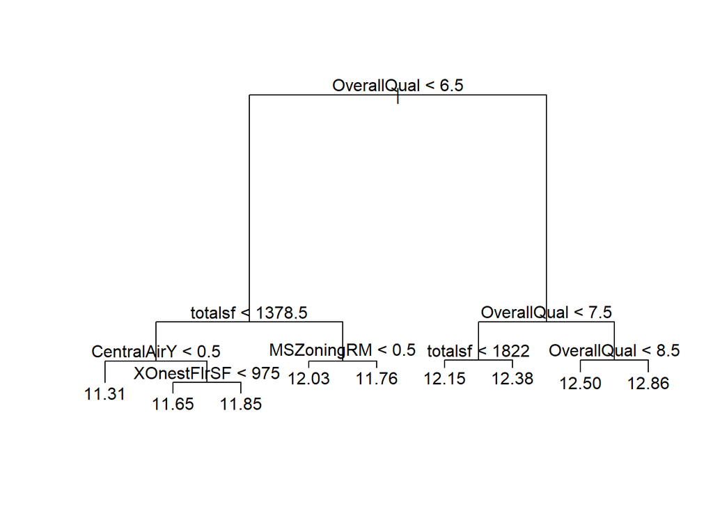

```r
plot(tree1)
text(tree1, pretty = 0)
```

```r
summary(tree1)
```

```
##
## Regression tree:
## tree(formula = SalePrice ~ ., data = train.final)
## Variables actually used in tree construction:
## [1] "OverallQual" "totalsf"     "CentralAirY" "XOnestFlrSF" "MSZoningRM"
## Number of terminal nodes:  9
## Residual mean deviance:  0.04216 = 60.92 / 1445
## Distribution of residuals:
##     Min.  1st Qu.   Median     Mean  3rd Qu.     Max.
## -0.84850 -0.11130  0.01499  0.00000  0.12340  0.69880
```

So, it looks like the variables used to “grow” the tree are OverallQuality, totalsf, CentralAirY, First Floor Square Feet, and Residential Medium Density Zoning.

The most important predictor of Sale Price is Overall Quality; houses that have an overall quality greater than 6.5 tend to have a higher Sale Price than houses with a lower overaLl quality.

The houses that sold for the most money have an overall quality greater than 8.5.

The houses that sold for the least money have an overall quality less than 6.5, have total square feet less than 1378.5, and do not have central air.

## 8.3 Select the Optimal Number of Nodes

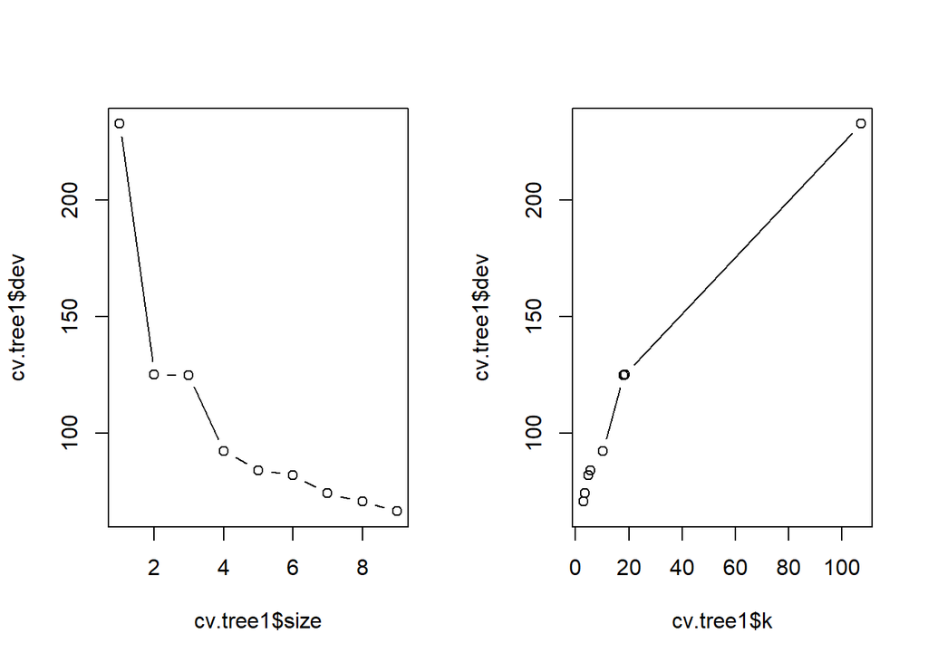

```r
cv.tree1 <- cv.tree(tree1, FUN = prune.tree, K = 10)
par(mfrow = c(1, 2))
plot(cv.tree1$size, cv.tree1$dev, type = "b")
plot(cv.tree1$k, cv.tree1$dev, type = "b")
```

```r
best.size <- cv.tree1$size[which.min(cv.tree1$dev)]
best.size
```

```
## [1] 9
```

I chose the tuning parameter through cross-validation. The best size selected through cross-validation is 9. This is the same size as the initial tree that we “grew”, so the pruned tree will be exactly the same as the initial model:

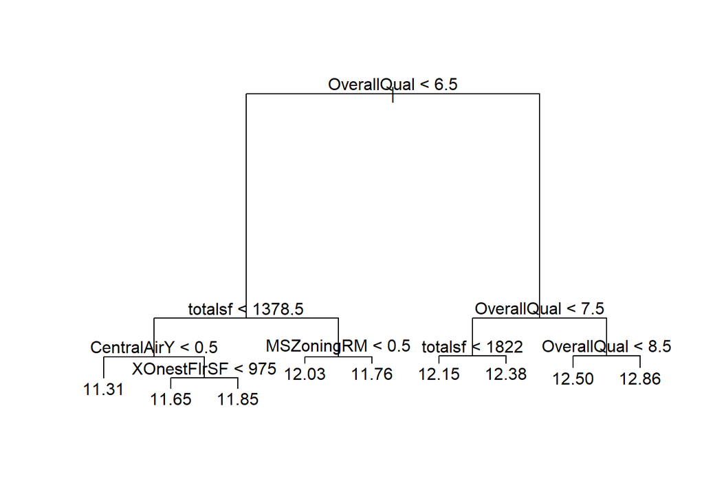

```r
prune.tree1 <- prune.tree(tree1, best = best.size)
plot(prune.tree1)
text(prune.tree1, pretty = 0)
```

## 8.4 Estimated Test Error

Here, use 10-fold cross validation to estimate the test RMSE:

```r
fold.index <- cut(sample(1:nrow(train.final)), breaks = 10, labels = FALSE)
trainCV <- train.final
trainCV$Fold <- fold.index
MSE.list <- c()

for (i in 1:10) {
    temp.train <- trainCV[trainCV$Fold != i, ] %>% dplyr::select(-c(Fold))
    temp.test <- trainCV[trainCV$Fold == i, ] %>% dplyr::select(-c(Fold,
        SalePrice))
    actual <- trainCV[trainCV$Fold == i, ] %>% dplyr::select(SalePrice)
    temp.pred <- predict(tree(SalePrice ~ ., data = temp.train), temp.test)
    MSE.list[i] <- sqrt(mean(((actual[, 1]) - (temp.pred))^2))
}
cv.rmse.regression.tree <- mean(MSE.list)
```

Finally, make predictions on the regression tree.

```r
regression.tree.predictions <- exp(predict(tree1, test.final))
```

# 9 Random Forest

## 9.1 Create the Model

First, create the model using the default number of trees (500) and the maximum predictors to try at each node of $\frac{p}{3}$.

```r
rf.1 <- randomForest(SalePrice ~ ., data = train.final, mtry = ceiling((ncol(train.final) -
    1)/3), importance = TRUE)
```

## 9.2 Parameter Tuning

But, in the text book, they recommend two different values of mtry: both $\sqrt p$ and $\frac{p}{3}$. Use 5-fold cross validation to find the best parameter to use:

```r
rf.train <- train.final
fold.index <- cut(sample(1:nrow(rf.train)), breaks = 5, labels = FALSE)
rf.train$fold.index <- fold.index

count <- 1
matrix <- matrix(data = NA, nrow = 2, ncol = 2)

for (method in c("square.root", "p/3")) {
    temp.vect <- c()
    temp.mtry <- ifelse(method == "square.root", sqrt(ncol(train.final) -
        1), ((ncol(train.final) - 1)/3))
    for (i in 1:5) {
        temp.train <- rf.train %>% dplyr::filter(fold.index != i) %>% dplyr::select(-c(fold.index))
        temp.test <- rf.train %>% dplyr::filter(fold.index == i) %>% dplyr::select(-c(fold.index,
            SalePrice))
        actual <- rf.train %>% dplyr::filter(fold.index == i) %>% dplyr::select(SalePrice)


        temp.model <- randomForest(SalePrice ~ ., data = temp.train, mtry = temp.mtry,
            ntree = 500)

        predict <- predict(temp.model, temp.test)

        temp.vect[i] <- sqrt(mean(actual[, 1] - predict)^2)

    }
    matrix[count, 1] <- method
    matrix[count, 2] <- mean(temp.vect)
    count <- count + 1
}

matrix
```

```
##      [,1]          [,2]
## [1,] "square.root" "0.00752964550254978"
## [2,] "p/3"         "0.00632915305700274"
```

So, using the number of trees, the $\frac{p}{3}$ method yields a slightly lower RMSE.

Now, use a grid search to select the optimal number of trees, using $\frac{p}{3}$ as mtry:

```r
rf.train <- train.final
fold.index <- cut(sample(1:nrow(rf.train)), breaks = 5, labels = FALSE)
rf.train$fold.index <- fold.index

count <- 1
matrix <- matrix(data = NA, nrow = 10, ncol = 2)

for (temp.tree in seq(50, 500, 50)) {
    temp.vect <- c()
    for (i in 1:5) {
        temp.train <- rf.train %>% dplyr::filter(fold.index != i) %>% dplyr::select(-c(fold.index))
        temp.test <- rf.train %>% dplyr::filter(fold.index == i) %>% dplyr::select(-c(fold.index,
            SalePrice))
        actual <- rf.train %>% dplyr::filter(fold.index == i) %>% dplyr::select(SalePrice)


        temp.model <- randomForest(SalePrice ~ ., data = temp.train, mtry = 84,
            ntree = temp.tree)

        predict <- predict(temp.model, temp.test)

        temp.vect[i] <- sqrt(mean(actual[, 1] - predict)^2)

    }
    matrix[count, 1] <- temp.tree
    matrix[count, 2] <- mean(temp.vect)
    count <- count + 1
}

matrix
```

```
##       [,1]        [,2]
##  [1,]   50 0.006761253
##  [2,]  100 0.008040024
##  [3,]  150 0.007442157
##  [4,]  200 0.007844334
##  [5,]  250 0.007512287
##  [6,]  300 0.007642777
##  [7,]  350 0.007429634
##  [8,]  400 0.007379584
##  [9,]  450 0.007225748
## [10,]  500 0.007504414
```

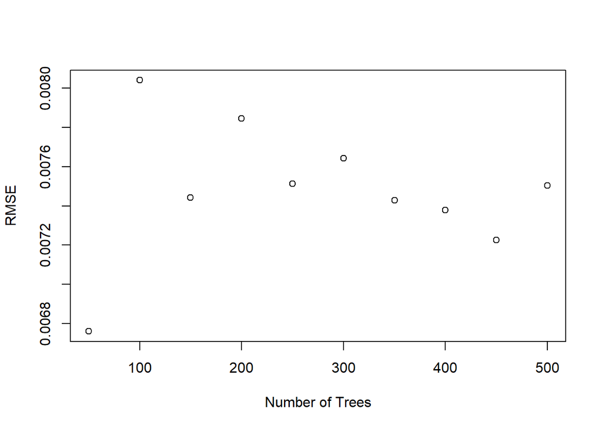

```r
plot(matrix[, 2] ~ matrix[, 1], xlab = "Number of Trees", ylab = "RMSE")
```

Evident in the plot, there is no obvious relationship between number of trees in the model and RMSE, which is unexpected.

So, moving forward, I’ll use the default number of trees: 500. Further, the random forest with 500 trees has a relatively low RMSE, and using more trees would take a long time to compute.

## 9.3 Estimated Test Error

Here, use 5-fold cross validation to estimate the test RMSE:

```r
fold.index <- cut(sample(1:nrow(train.final)), breaks = 5, labels = FALSE)
trainCV <- train.final
trainCV$Fold <- fold.index
MSE.list <- c()

for (i in 1:5) {
    temp.train <- trainCV[trainCV$Fold != i, ] %>% dplyr::select(-c(Fold))
    temp.test <- trainCV[trainCV$Fold == i, ] %>% dplyr::select(-c(Fold,
        SalePrice))

    actual <- trainCV[trainCV$Fold == i, ] %>% dplyr::select(SalePrice)

    temp.pred <- predict(randomForest(SalePrice ~ ., data = temp.train,
        mtry = ceiling((ncol(trainCV) - 1)/3), importance = TRUE), temp.test)

    MSE.list[i] <- sqrt(mean(((temp.pred) - (actual[, 1]))^2))
}
cv.rmse.random.forest <- mean(MSE.list)
```

## 9.4 Interpretation

Note, I only selected the ten most important predictors to display.

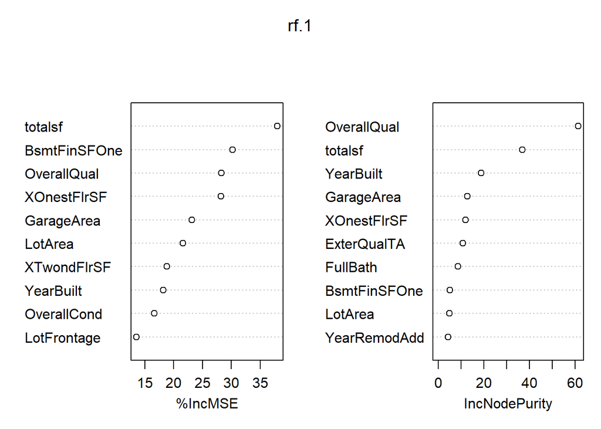

```r
varImpPlot(rf.1, n.var = 10)
```

So, the most important predictors in terms of node purity are overally quality, total square feet, year built, and garage area.

The most important predictors in terms of %IncMSE are total square feet, the total square feet of the finished basement, and overall quality.

The regression tree had many of the same important predictors. Notably, however, the regression tree included central air, while this predictor is not the in top ten most important by either the %IncMSE or Node Purity metrics.

## 9.5 Predictions

Make predictions:

```r
random.forest.pred <- data.frame(SalePrice = predict(rf.1, test.final))
```

# 10 Bagging

## 10.1 Build the Model

Bagging is simply a random forest, with mtry set to the number of predictors.

```r
predictors <- ncol(train.final) - 1

bag.1 <- randomForest(SalePrice ~ ., data = train.final, mtry = predictors,
    importance = TRUE)

bag.1
```

```
##
## Call:
##  randomForest(formula = SalePrice ~ ., data = train.final, mtry = predictors,      importance = TRUE)
##                Type of random forest: regression
##                      Number of trees: 500
## No. of variables tried at each split: 252
##
##           Mean of squared residuals: 0.01901742
##                     % Var explained: 88.08
```

## 10.2 Parameter Tuning

Now, I will choose the tuning parameter to use in this model: the number of trees. This is very similar to what I did for Random Forest.

```r
bagging.train <- train.final
fold.index <- cut(sample(1:nrow(bagging.train)), breaks = 5, labels = FALSE)
bagging.train$fold.index <- fold.index

count <- 1
matrix <- matrix(data = NA, nrow = 5, ncol = 2)

for (temp.tree in seq(100, 500, 100)) {
    temp.vect <- c()
    for (i in 1:5) {
        temp.train <- bagging.train %>% dplyr::filter(fold.index != i) %>%
            dplyr::select(-c(fold.index))
        temp.test <- bagging.train %>% dplyr::filter(fold.index == i) %>%
            dplyr::select(-c(fold.index, SalePrice))
        actual <- bagging.train %>% dplyr::filter(fold.index == i) %>%
            dplyr::select(SalePrice)


        temp.model <- randomForest(SalePrice ~ ., data = temp.train, mtry = (ncol(bagging.train) -
            2), ntree = temp.tree)

        predict <- predict(temp.model, temp.test)

        temp.vect[i] <- sqrt(mean(actual[, 1] - predict)^2)
        message(i)
    }
    matrix[count, 1] <- temp.tree
    matrix[count, 2] <- mean(temp.vect)
    count <- count + 1
}

matrix
```

```
##      [,1]        [,2]
## [1,]  100 0.005118272
## [2,]  200 0.005124860
## [3,]  300 0.004911622
## [4,]  400 0.005251177
## [5,]  500 0.004842759
```

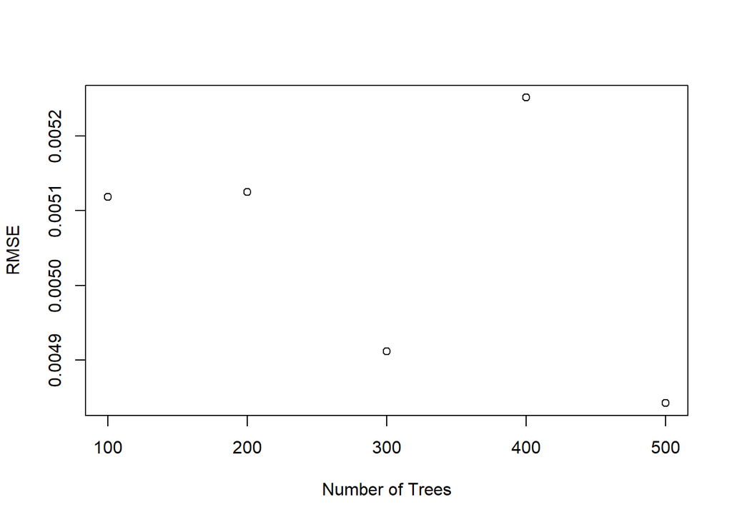

```r
plot(matrix[, 2] ~ matrix[, 1], xlab = "Number of Trees", ylab = "RMSE")
```

Similar to the random forest, there is surprisingly no pattern in the error plot. So, I will use the default number of trees.

## 10.3 Interpretation

Note that I only display the 10 most important predictors, so the plot can actually be interpreted.

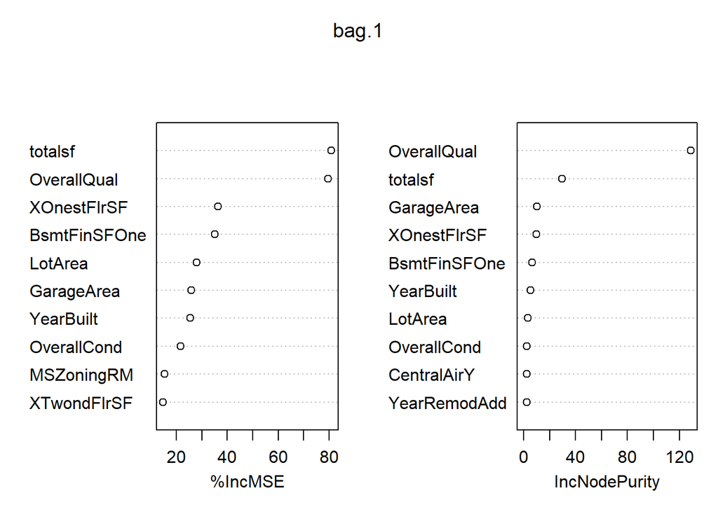

```r
varImpPlot(bag.1, n.var = 10)
```

These predictors are very similar to the ones in the random forest model.

## 10.4 Estimated Test Error

```r
fold.index <- cut(sample(1:nrow(train.final)), breaks = 5, labels = FALSE)
trainBag <- train.final
trainBag$Fold <- fold.index
MSE.list <- c()

for (i in 1:5) {
    temp.train <- trainBag[trainBag$Fold != i, ] %>% dplyr::select(-c(Fold))
    temp.test <- trainBag[trainBag$Fold == i, ] %>% dplyr::select(-c(Fold,
        SalePrice))

    actual <- trainBag[trainBag$Fold == i, ] %>% dplyr::select(SalePrice)

    temp.model <- randomForest(SalePrice ~ ., data = temp.train, mtry = (ncol(bagging.train) -
        2))

    temp.pred <- predict(temp.model, temp.test)

    MSE.list[i] <- sqrt(mean(((temp.pred) - (actual[, 1]))^2))
}
cv.rmse.bagging <- mean(MSE.list)
```

## 10.5 Predictions

```r
bag.predictions <- predict(bag.1, test.final)
```

# 11 Boosting

## 11.1 Build Model

```r
boost.1 <- gbm(SalePrice ~ ., data = train.final, distribution = "gaussian",
    shrinkage = 0.01, n.tree = 5000, interaction.depth = 4)
```

## 11.2 Parameter Tuning

Here, use cross-fold validation to select the best number of trees to use in the model.

```r
boost.cv <- gbm(SalePrice ~ ., data = train.final, distribution = "gaussian",
    shrinkage = 0.01, n.tree = 5000, interaction.depth = 4, cv.folds = 10)
boost.cv
```

```
## gbm(formula = SalePrice ~ ., distribution = "gaussian", data = train.final,
##     n.trees = 5000, interaction.depth = 4, shrinkage = 0.01,
##     cv.folds = 10)
## A gradient boosted model with gaussian loss function.
## 5000 iterations were performed.
## The best cross-validation iteration was 3769.
## There were 252 predictors of which 190 had non-zero influence.
```

Here is the optimal number of trees which I will use in the model:

```r
which.min(boost.cv$cv.error)
```

```
## [1] 3769
```

## 11.3 Refit Model

```r
boost.2 <- gbm(SalePrice ~ ., data = train.final, distribution = "gaussian",
    shrinkage = 0.01, n.tree = which.min(boost.cv$cv.error), interaction.depth = 4)
```

## 11.4 Interpretation

```r
summary.gbm(boost.2, plotit = FALSE)
```

```
##                                               var      rel.inf
## OverallQual                           OverallQual 3.613311e+01
## totalsf                                   totalsf 1.967545e+01
## YearBuilt                               YearBuilt 5.612862e+00
## GarageArea                             GarageArea 5.461524e+00
## XOnestFlrSF                           XOnestFlrSF 4.872389e+00
## BsmtFinSFOne                         BsmtFinSFOne 3.178943e+00
## LotArea                                   LotArea 2.368584e+00
## YearRemodAdd                         YearRemodAdd 2.247382e+00
## OverallCond                           OverallCond 1.919259e+00
## CentralAirN                           CentralAirN 1.151308e+00
## Fireplaces                             Fireplaces 9.618074e-01
## ExterQualTA                           ExterQualTA 8.291138e-01
## CentralAirY                           CentralAirY 7.059400e-01
## GarageTypeAttchd                 GarageTypeAttchd 6.982399e-01
## BsmtUnfSF                               BsmtUnfSF 6.813658e-01
## BsmtQualEx                             BsmtQualEx 6.703862e-01
## FireplaceQunoFireplace     FireplaceQunoFireplace 6.282809e-01
## LotFrontage                           LotFrontage 6.030469e-01
## OpenPorchSF                           OpenPorchSF 5.102473e-01
## MSZoningRM                             MSZoningRM 4.606122e-01
## KitchenQualEx                       KitchenQualEx 4.303376e-01
## MSZoningRL                             MSZoningRL 4.174298e-01
## WoodDeckSF                             WoodDeckSF 4.035111e-01
## SaleConditionAbnorml         SaleConditionAbnorml 3.398901e-01
## KitchenQualTA                       KitchenQualTA 3.366838e-01
## XTwondFlrSF                           XTwondFlrSF 3.353571e-01
## FullBath                                 FullBath 3.180254e-01
## NeighborhoodCrawfor           NeighborhoodCrawfor 3.017820e-01
## MoSold                                     MoSold 3.003962e-01
## EnclosedPorch                       EnclosedPorch 2.687817e-01
## NeighborhoodIDOTRR             NeighborhoodIDOTRR 2.674873e-01
## SaleConditionNormal           SaleConditionNormal 2.665906e-01
## FunctionalTyp                       FunctionalTyp 2.643396e-01
## YrSold                                     YrSold 2.532412e-01
## BsmtExposureGd                     BsmtExposureGd 2.456431e-01
## GarageCondTA                         GarageCondTA 2.388543e-01
## BsmtFullBath                         BsmtFullBath 2.180569e-01
## KitchenAbvGr                         KitchenAbvGr 1.976170e-01
## GarageTypeDetchd                 GarageTypeDetchd 1.855164e-01
```

[output cut: 198 more lines]

```
## GarageQualGd                         GarageQualGd 0.000000e+00
## GarageQualnoGarage             GarageQualnoGarage 0.000000e+00
## GarageCondGd                         GarageCondGd 0.000000e+00
## GarageCondnoGarage             GarageCondnoGarage 0.000000e+00
## GarageCondPo                         GarageCondPo 0.000000e+00
## PoolQCnoPool                         PoolQCnoPool 0.000000e+00
## FenceGdPrv                             FenceGdPrv 0.000000e+00
## FenceMnWw                               FenceMnWw 0.000000e+00
## MiscFeatureShed                   MiscFeatureShed 0.000000e+00
## SaleTypeConLD                       SaleTypeConLD 0.000000e+00
## SaleTypeConLI                       SaleTypeConLI 0.000000e+00
## SaleTypeConLw                       SaleTypeConLw 0.000000e+00
## SaleTypeCWD                           SaleTypeCWD 0.000000e+00
## SaleConditionAdjLand         SaleConditionAdjLand 0.000000e+00
## SaleConditionAlloca           SaleConditionAlloca 0.000000e+00
```

Here, plot only the top ten most important predictors:

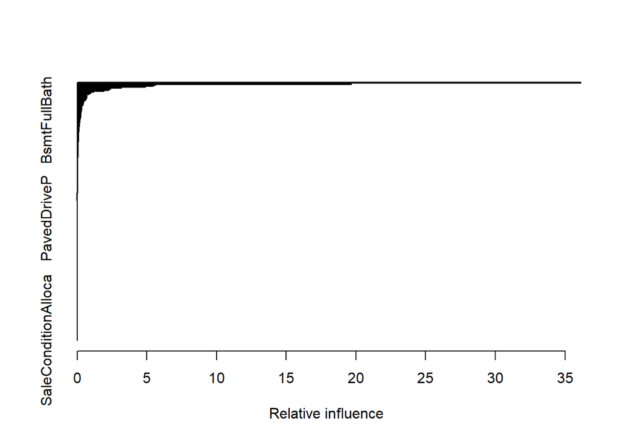

```r
plot.data <- summary.gbm(boost.2)[1:10, ]
```

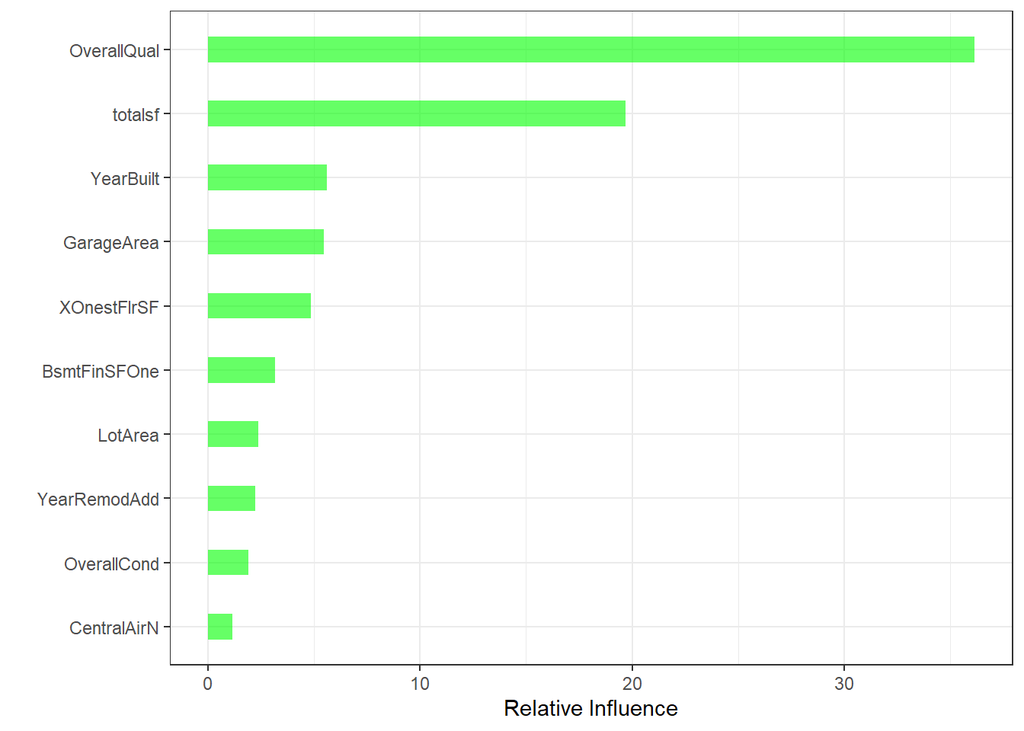

```r
plot.data %>% mutate(var = fct_reorder(var, rel.inf)) %>% ggplot(aes(x = var,
    y = rel.inf)) + geom_bar(stat = "identity", fill = "green", alpha = 0.6,
    width = 0.4) + coord_flip() + xlab("") + ylab("Relative Influence") +
    theme_bw()
```

## 11.5 Estimated Test Error

Note that I initially ran into an error, because when I split the data into 10 partitions, some of the training sets only had one unique value in a predictor column.

So, to avoid this error, I filtered to only used the columns where both the testing and training set had at least 2 unique values in each predictor column. While this may give an inaccurate representation of test error, this was the only method I could get the loop to actually work.

```r
trainBoost <- train.final
fold.index <- cut(sample(1:nrow(trainBoost)), breaks = 10, labels = FALSE)
trainBoost$Fold <- fold.index

MSE.list <- c()

for (i in c(1)) {
    temp.train <- trainBoost[trainBoost$Fold != i, ] %>% dplyr::filter(Fold !=
        i) %>% dplyr::select(-c(Fold))

    temp.test <- trainBoost %>% dplyr::filter(Fold == i) %>% dplyr::select(-c(Fold))

    unique.vect1 <- c()
    for (j in 1:ncol(temp.test)) {
        unique.vect1[j] <- length(unique(temp.test[, j]))
    }


    unique.vect2 <- c()
    for (k in 1:ncol(temp.train)) {
        unique.vect2[k] <- length(unique(temp.train[, k]))
    }

    include <- intersect(colnames(temp.test)[unique.vect1 != 1], colnames(temp.train)[unique.vect2 !=
        1])


    temp.train <- temp.train %>% dplyr::select(c(include, "SalePrice"))

    actual <- temp.test %>% dplyr::select(SalePrice)

    temp.test <- temp.test %>% dplyr::select(include) %>% dplyr::select(-c(SalePrice))



    temp.boost <- gbm(SalePrice ~ ., data = temp.train, distribution = "gaussian",
        shrinkage = 0.01, n.tree = which.min(boost.cv$cv.error), interaction.depth = 4)

    temp.pred <- predict(temp.boost, newdata = temp.test, n.trees = which.min(temp.boost$cv.error))

    MSE.list[i] <- sqrt(mean((log(temp.pred) - log(actual[, 1]))^2))
}
cv.rmse.boost <- mean(MSE.list)
cv.rmse.boost
```

```
## [1] 0.008769055
```

## 11.6 Predictions

```r
boost.pred <- predict(boost.cv, newdata = test.final, n.trees = which.min(boost.cv$cv.error))
```

# 12 GAM

## 12.1 Build a Model

First, I will use the same predictors as indicated in the best subset selection.

I tried to create a loop to try different degrees of freedom, and to avoid manually typing in the equation for each model, but that proved to be a challenge.

So, I first converted the binary 0, 1 values to factors. Then, I included the factors in a string. I added to the string each quantitative variable, in the form s(colname, j).

Now, all I have to do is copy paste this expression in a loop with varying degrees of freedom to investigate the best degrees of freedom to use!

```r
best.fit <- regsubsets(SalePrice ~ ., data = train.final, nvmax = 150,
    method = "forward")
```

```
## Reordering variables and trying again:
```

```r
gam.to.include <- row.names(as.data.frame(coef(best.fit, 98)))
gam.to.include <- gam.to.include[gam.to.include != "(Intercept)"]

train.gam <- train.final %>% dplyr::select(c(gam.to.include, "SalePrice"))

for (i in 1:ncol(train.gam)) {
    if (unique(train.gam[, i])[1] %in% c(0, 1)) {
        train.gam[, i] <- as.factor(train.gam[, i])
    }
}
expression <- c()
for (i in 1:ncol(train.gam)) {
    if (is.numeric(train.gam[, i]) & colnames(train.gam)[i] != "SalePrice") {
        expression <- paste(expression, " s(", colnames(train.gam)[i],
            ", j) +", sep = "")
    }
}

for (i in 1:ncol(train.gam)) {
    if (is.factor(train.gam[, i])) {
        if (i == (ncol(train.gam) - 2)) {
            expression <- paste(expression, colnames(train.gam[i]), sep = " ")
        } else {
            expression <- paste(expression, colnames(train.gam[i]), "+",
                sep = " ")
        }
    }
}


final.expression <- paste("SalePrice ~", expression)
final.expression
```

```
## [1] "SalePrice ~  s(LotFrontage, j) + s(LotArea, j) + s(YearRemodAdd, j) + s(XOnestFlrSF, j) + s(XTwondFlrSF, j) + s(BedroomAbvGr, j) + s(TotRmsAbvGrd, j) + s(YrSold, j) + s(totalsf, j) + MSZoningCAll + MSZoningRL + StreetGrvl + AlleyGrvl + LotShapeIRThree + NeighborhoodBlmngtn + NeighborhoodBrDa…
```

Here, I will create a matrix of p-values. For degrees of freedom from 2 to 8, I will populate the matrix with p-values of the nonparametric terms for each of the quantitative predictors.

```r
p.value.matrix <- matrix(data = NA, nrow = 9, ncol = 7)
row.names(p.value.matrix) = c("Lot Frontage", "LotArea", "YearRemodAdd",
    "First Floor SF", "Second Floor SF", "Bedrooms Above Ground", "Total Rooms Above Ground",
    "YrSold", "TotalSF")
colnames(p.value.matrix) <- c(2:8)

for (j in 2:8) {
    temp.model <- gam(SalePrice ~ s(LotFrontage, j) + s(LotArea, j) + s(YearRemodAdd,
        j) + s(XOnestFlrSF, j) + s(XTwondFlrSF, j) + s(BedroomAbvGr, j) +
        s(TotRmsAbvGrd, j) + s(YrSold, j) + s(totalsf, j) + MSZoningCAll +
        MSZoningRL + StreetGrvl + AlleyGrvl + LotShapeIRThree + NeighborhoodBlmngtn +
        NeighborhoodBrDale + NeighborhoodEdwards + NeighborhoodGilbert +
        NeighborhoodMeadowV + NeighborhoodMitchel + NeighborhoodNoRidge +
        NeighborhoodNPkVill + NeighborhoodOldTown + NeighborhoodSawyer +
        NeighborhoodSomerst + NeighborhoodStoneBr + NeighborhoodSWISU +
        NeighborhoodTimber + ConditionOneNorm + ConditionOnePosA + ConditionOneRRAn +
        ConditionOneRRNn + ConditionTwoNorm + BldgTypeTwofmCon + BldgTypeDuplex +
        RoofStyleFlat + RoofStyleGable + RoofMatlCompShg + RoofMatlTarGrv +
        RoofMatlWdShake + RoofMatlWdShngl + ExteriorOnestWdSdng + ExteriorTwondAsbShng +
        ExteriorTwondBrkFace + ExteriorTwondCmentBd + ExteriorTwondHdBoard +
        ExteriorTwondPlywood + ExteriorTwondWdSdng + ExterCondFa + FoundationBrkTil +
        FoundationPConc + BsmtCondGd + BsmtExposureAv + BsmtExposureGd +
        BsmtFinTypeOneALQ + BsmtFinTypeOneBLQ + BsmtFinTypeTwoALQ + BsmtFinSFTwo +
        HeatingGasA + HeatingGrav + HeatingQCEx + ElectricalFuseF + HalfBath +
        KitchenAbvGr + KitchenQualFa + FunctionalMajTwo + FunctionalMod +
        FireplaceQuPo + GarageTypeTwoTypes + GarageTypeBasment + GarageTypeBuiltIn +
        GarageTypeDetchd + GarageFinishFin + GarageQualTA + GarageCondFa +
        GarageCondTA + PavedDriveN + EnclosedPorch + ScreenPorch + FenceGdWo +
        SaleTypeCWD + SaleTypeNew + SaleConditionAlloca + StreetPave +
        LandContourLvl + LotConfigInside + LandSlopeSev + BldgTypeTwnhsE +
        HouseStyleSLvl + MasVnrTypeStone + BsmtQualTA + BsmtFinTypeOnenoBasement +
        CentralAirY + FireplaceQuTA + GarageTypenoGarage + GarageQualnoGarage +
        GarageCondnoGarage + FencenoFence, data = train.final)

    temp.summary <- summary(temp.model)
    p.value.matrix[, (j - 1)] <- temp.summary$anova[2:10, 3]
}
```

```r
p.value.matrix < 0.05
```

```
##                              2     3     4     5     6     7     8
## Lot Frontage             FALSE FALSE FALSE FALSE FALSE FALSE  TRUE
## LotArea                  FALSE FALSE FALSE  TRUE  TRUE  TRUE  TRUE
## YearRemodAdd             FALSE FALSE FALSE  TRUE  TRUE  TRUE  TRUE
## First Floor SF           FALSE FALSE  TRUE  TRUE  TRUE  TRUE  TRUE
## Second Floor SF          FALSE FALSE FALSE FALSE  TRUE  TRUE  TRUE
## Bedrooms Above Ground    FALSE FALSE FALSE  TRUE  TRUE  TRUE  TRUE
## Total Rooms Above Ground FALSE FALSE FALSE FALSE FALSE FALSE FALSE
## YrSold                   FALSE FALSE  TRUE  TRUE  TRUE  TRUE  TRUE
## TotalSF                  FALSE  TRUE  TRUE  TRUE  TRUE  TRUE  TRUE
```

Some notes based on this p-value matrix:

Total Rooms Above Ground is never significantly transformed.

Generally, the significance of the nonparametric terms in the model changes based on the degrees of freedom.

Now, to find the best degrees of freedom, I will build 7 models, with degrees of freedom 2 to 8.

For each model, I will remove the natural spline term from the quantitative predictors where the nonparametric effect is not significant.

Finally, I will perform 10-fold cross validation to estimate test error. I will choose the model that minimizes test error.

```r
gam.train <- train.final
fold.index <- cut(sample(1:nrow(gam.train)), breaks = 10, labels = FALSE)
gam.train$Fold <- fold.index
MSE.list <- c()
```

### 12.1.1 2 Degrees of Freedom

This has no nonparametric terms added.

```r
MSE.list.2.df <- c()
for (i in 1:10) {
    temp.train <- gam.train[gam.train$Fold != i, ] %>% dplyr::select(-c(Fold))
    temp.test <- gam.train[gam.train$Fold == i, ] %>% dplyr::select(-c(Fold,
        SalePrice))
    actual <- gam.train[gam.train$Fold == i, ] %>% dplyr::select(SalePrice)
    temp.model.2.df <- gam(SalePrice ~ LotFrontage + LotArea + YearRemodAdd +
        XOnestFlrSF + XTwondFlrSF + BedroomAbvGr + TotRmsAbvGrd + YrSold +
        totalsf + MSZoningCAll + MSZoningRL + StreetGrvl + AlleyGrvl +
        LotShapeIRThree + NeighborhoodBlmngtn + NeighborhoodBrDale + NeighborhoodEdwards +
        NeighborhoodGilbert + NeighborhoodMeadowV + NeighborhoodMitchel +
        NeighborhoodNoRidge + NeighborhoodNPkVill + NeighborhoodOldTown +
        NeighborhoodSawyer + NeighborhoodSomerst + NeighborhoodStoneBr +
        NeighborhoodSWISU + NeighborhoodTimber + ConditionOneNorm + ConditionOnePosA +
        ConditionOneRRAn + ConditionOneRRNn + ConditionTwoNorm + BldgTypeTwofmCon +
        BldgTypeDuplex + RoofStyleFlat + RoofStyleGable + RoofMatlCompShg +
        RoofMatlTarGrv + RoofMatlWdShake + RoofMatlWdShngl + ExteriorOnestWdSdng +
        ExteriorTwondAsbShng + ExteriorTwondBrkFace + ExteriorTwondCmentBd +
        ExteriorTwondHdBoard + ExteriorTwondPlywood + ExteriorTwondWdSdng +
        ExterCondFa + FoundationBrkTil + FoundationPConc + BsmtCondGd +
        BsmtExposureAv + BsmtExposureGd + BsmtFinTypeOneALQ + BsmtFinTypeOneBLQ +
        BsmtFinTypeTwoALQ + BsmtFinSFTwo + HeatingGasA + HeatingGrav +
        HeatingQCEx + ElectricalFuseF + HalfBath + KitchenAbvGr + KitchenQualFa +
        FunctionalMajTwo + FunctionalMod + FireplaceQuPo + GarageTypeTwoTypes +
        GarageTypeBasment + GarageTypeBuiltIn + GarageTypeDetchd + GarageFinishFin +
        GarageQualTA + GarageCondFa + GarageCondTA + PavedDriveN + EnclosedPorch +
        ScreenPorch + FenceGdWo + SaleTypeCWD + SaleTypeNew + SaleConditionAlloca +
        StreetPave + LandContourLvl + LotConfigInside + LandSlopeSev +
        BldgTypeTwnhsE + HouseStyleSLvl + MasVnrTypeStone + BsmtQualTA +
        BsmtFinTypeOnenoBasement + CentralAirY + FireplaceQuTA + GarageTypenoGarage +
        GarageQualnoGarage + GarageCondnoGarage + FencenoFence, data = temp.train)

    temp.pred <- predict.lm(temp.model.2.df, temp.test)
    MSE.list.2.df[i] <- sqrt(mean(((actual[, 1]) - (temp.pred))^2))
}
cv.gam.2 <- mean(MSE.list.2.df)
```

### 12.1.2 3 Degrees of Freedom

The only nonparametric term is total square feet.

```r
MSE.list.3.df <- c()
for (i in 1:10) {
    temp.train <- gam.train[gam.train$Fold != i, ] %>% dplyr::select(-c(Fold))
    temp.test <- gam.train[gam.train$Fold == i, ] %>% dplyr::select(-c(Fold,
        SalePrice))
    actual <- gam.train[gam.train$Fold == i, ] %>% dplyr::select(SalePrice)
    temp.model.3.df <- gam(SalePrice ~ LotFrontage + LotArea + YearRemodAdd +
        XOnestFlrSF + XTwondFlrSF + BedroomAbvGr + TotRmsAbvGrd + YrSold +
        s(totalsf, 3) + MSZoningCAll + MSZoningRL + StreetGrvl + AlleyGrvl +
        LotShapeIRThree + NeighborhoodBlmngtn + NeighborhoodBrDale + NeighborhoodEdwards +
        NeighborhoodGilbert + NeighborhoodMeadowV + NeighborhoodMitchel +
        NeighborhoodNoRidge + NeighborhoodNPkVill + NeighborhoodOldTown +
        NeighborhoodSawyer + NeighborhoodSomerst + NeighborhoodStoneBr +
        NeighborhoodSWISU + NeighborhoodTimber + ConditionOneNorm + ConditionOnePosA +
        ConditionOneRRAn + ConditionOneRRNn + ConditionTwoNorm + BldgTypeTwofmCon +
        BldgTypeDuplex + RoofStyleFlat + RoofStyleGable + RoofMatlCompShg +
        RoofMatlTarGrv + RoofMatlWdShake + RoofMatlWdShngl + ExteriorOnestWdSdng +
        ExteriorTwondAsbShng + ExteriorTwondBrkFace + ExteriorTwondCmentBd +
        ExteriorTwondHdBoard + ExteriorTwondPlywood + ExteriorTwondWdSdng +
        ExterCondFa + FoundationBrkTil + FoundationPConc + BsmtCondGd +
        BsmtExposureAv + BsmtExposureGd + BsmtFinTypeOneALQ + BsmtFinTypeOneBLQ +
        BsmtFinTypeTwoALQ + BsmtFinSFTwo + HeatingGasA + HeatingGrav +
        HeatingQCEx + ElectricalFuseF + HalfBath + KitchenAbvGr + KitchenQualFa +
        FunctionalMajTwo + FunctionalMod + FireplaceQuPo + GarageTypeTwoTypes +
        GarageTypeBasment + GarageTypeBuiltIn + GarageTypeDetchd + GarageFinishFin +
        GarageQualTA + GarageCondFa + GarageCondTA + PavedDriveN + EnclosedPorch +
        ScreenPorch + FenceGdWo + SaleTypeCWD + SaleTypeNew + SaleConditionAlloca +
        StreetPave + LandContourLvl + LotConfigInside + LandSlopeSev +
        BldgTypeTwnhsE + HouseStyleSLvl + MasVnrTypeStone + BsmtQualTA +
        BsmtFinTypeOnenoBasement + CentralAirY + FireplaceQuTA + GarageTypenoGarage +
        GarageQualnoGarage + GarageCondnoGarage + FencenoFence, data = temp.train)

    temp.pred <- predict.lm(temp.model.3.df, temp.test)
    MSE.list.3.df[i] <- sqrt(mean(((actual[, 1]) - (temp.pred))^2))
}
cv.gam.3 <- mean(MSE.list.3.df)
```

### 12.1.3 4 Degrees of Freedom

First floor square feet, year sold, and total square feet all have nonparametric terms.

```r
MSE.list.4.df <- c()
for (i in 1:10) {
    temp.train <- gam.train[gam.train$Fold != i, ] %>% dplyr::select(-c(Fold))
    temp.test <- gam.train[gam.train$Fold == i, ] %>% dplyr::select(-c(Fold,
        SalePrice))
    actual <- gam.train[gam.train$Fold == i, ] %>% dplyr::select(SalePrice)
    temp.model.4.df <- gam(SalePrice ~ LotFrontage + LotArea + YearRemodAdd +
        s(XOnestFlrSF, 4) + XTwondFlrSF + BedroomAbvGr + TotRmsAbvGrd +
        s(YrSold, 4) + s(totalsf, 4) + MSZoningCAll + MSZoningRL + StreetGrvl +
        AlleyGrvl + LotShapeIRThree + NeighborhoodBlmngtn + NeighborhoodBrDale +
        NeighborhoodEdwards + NeighborhoodGilbert + NeighborhoodMeadowV +
        NeighborhoodMitchel + NeighborhoodNoRidge + NeighborhoodNPkVill +
        NeighborhoodOldTown + NeighborhoodSawyer + NeighborhoodSomerst +
        NeighborhoodStoneBr + NeighborhoodSWISU + NeighborhoodTimber +
        ConditionOneNorm + ConditionOnePosA + ConditionOneRRAn + ConditionOneRRNn +
        ConditionTwoNorm + BldgTypeTwofmCon + BldgTypeDuplex + RoofStyleFlat +
        RoofStyleGable + RoofMatlCompShg + RoofMatlTarGrv + RoofMatlWdShake +
        RoofMatlWdShngl + ExteriorOnestWdSdng + ExteriorTwondAsbShng +
        ExteriorTwondBrkFace + ExteriorTwondCmentBd + ExteriorTwondHdBoard +
        ExteriorTwondPlywood + ExteriorTwondWdSdng + ExterCondFa + FoundationBrkTil +
        FoundationPConc + BsmtCondGd + BsmtExposureAv + BsmtExposureGd +
        BsmtFinTypeOneALQ + BsmtFinTypeOneBLQ + BsmtFinTypeTwoALQ + BsmtFinSFTwo +
        HeatingGasA + HeatingGrav + HeatingQCEx + ElectricalFuseF + HalfBath +
        KitchenAbvGr + KitchenQualFa + FunctionalMajTwo + FunctionalMod +
        FireplaceQuPo + GarageTypeTwoTypes + GarageTypeBasment + GarageTypeBuiltIn +
        GarageTypeDetchd + GarageFinishFin + GarageQualTA + GarageCondFa +
        GarageCondTA + PavedDriveN + EnclosedPorch + ScreenPorch + FenceGdWo +
        SaleTypeCWD + SaleTypeNew + SaleConditionAlloca + StreetPave +
        LandContourLvl + LotConfigInside + LandSlopeSev + BldgTypeTwnhsE +
        HouseStyleSLvl + MasVnrTypeStone + BsmtQualTA + BsmtFinTypeOnenoBasement +
        CentralAirY + FireplaceQuTA + GarageTypenoGarage + GarageQualnoGarage +
        GarageCondnoGarage + FencenoFence, data = temp.train)

    temp.pred <- predict.lm(temp.model.4.df, temp.test)
    MSE.list.4.df[i] <- sqrt(mean(((actual[, 1]) - (temp.pred))^2))
}
cv.gam.4 <- mean(MSE.list.4.df)
```

### 12.1.4 Five degrees of freedom

Lot area, year remodel added, first floor square feet, bedrooms above ground, year sold, and total square feet all have nonparametric terms added.

```r
MSE.list.5.df <- c()
for (i in 1:10) {
    temp.train <- gam.train[gam.train$Fold != i, ] %>% dplyr::select(-c(Fold))
    temp.test <- gam.train[gam.train$Fold == i, ] %>% dplyr::select(-c(Fold,
        SalePrice))
    actual <- gam.train[gam.train$Fold == i, ] %>% dplyr::select(SalePrice)
    temp.model.5.df <- gam(SalePrice ~ LotFrontage + s(LotArea, 5) + s(YearRemodAdd,
        5) + s(XOnestFlrSF, 5) + XTwondFlrSF + s(BedroomAbvGr, 5) + TotRmsAbvGrd +
        s(YrSold, 5) + s(totalsf, 5) + MSZoningCAll + MSZoningRL + StreetGrvl +
        AlleyGrvl + LotShapeIRThree + NeighborhoodBlmngtn + NeighborhoodBrDale +
        NeighborhoodEdwards + NeighborhoodGilbert + NeighborhoodMeadowV +
        NeighborhoodMitchel + NeighborhoodNoRidge + NeighborhoodNPkVill +
        NeighborhoodOldTown + NeighborhoodSawyer + NeighborhoodSomerst +
        NeighborhoodStoneBr + NeighborhoodSWISU + NeighborhoodTimber +
        ConditionOneNorm + ConditionOnePosA + ConditionOneRRAn + ConditionOneRRNn +
        ConditionTwoNorm + BldgTypeTwofmCon + BldgTypeDuplex + RoofStyleFlat +
        RoofStyleGable + RoofMatlCompShg + RoofMatlTarGrv + RoofMatlWdShake +
        RoofMatlWdShngl + ExteriorOnestWdSdng + ExteriorTwondAsbShng +
        ExteriorTwondBrkFace + ExteriorTwondCmentBd + ExteriorTwondHdBoard +
        ExteriorTwondPlywood + ExteriorTwondWdSdng + ExterCondFa + FoundationBrkTil +
        FoundationPConc + BsmtCondGd + BsmtExposureAv + BsmtExposureGd +
        BsmtFinTypeOneALQ + BsmtFinTypeOneBLQ + BsmtFinTypeTwoALQ + BsmtFinSFTwo +
        HeatingGasA + HeatingGrav + HeatingQCEx + ElectricalFuseF + HalfBath +
        KitchenAbvGr + KitchenQualFa + FunctionalMajTwo + FunctionalMod +
        FireplaceQuPo + GarageTypeTwoTypes + GarageTypeBasment + GarageTypeBuiltIn +
        GarageTypeDetchd + GarageFinishFin + GarageQualTA + GarageCondFa +
        GarageCondTA + PavedDriveN + EnclosedPorch + ScreenPorch + FenceGdWo +
        SaleTypeCWD + SaleTypeNew + SaleConditionAlloca + StreetPave +
        LandContourLvl + LotConfigInside + LandSlopeSev + BldgTypeTwnhsE +
        HouseStyleSLvl + MasVnrTypeStone + BsmtQualTA + BsmtFinTypeOnenoBasement +
        CentralAirY + FireplaceQuTA + GarageTypenoGarage + GarageQualnoGarage +
        GarageCondnoGarage + FencenoFence, data = temp.train)

    temp.pred <- predict.lm(temp.model.5.df, temp.test)
    MSE.list.5.df[i] <- sqrt(mean(((actual[, 1]) - (temp.pred))^2))
}
cv.gam.5 <- mean(MSE.list.5.df)
```

### 12.1.5 Six degrees of freedom

Lot area, year remodel added, first floor square feet, second floor square feet, bedrooms above ground, year sold, and total square feet all have nonparametric terms added.

```r
MSE.list.6.df <- c()
for (i in 1:10) {
    temp.train <- gam.train[gam.train$Fold != i, ] %>% dplyr::select(-c(Fold))
    temp.test <- gam.train[gam.train$Fold == i, ] %>% dplyr::select(-c(Fold,
        SalePrice))
    actual <- gam.train[gam.train$Fold == i, ] %>% dplyr::select(SalePrice)
    temp.model.6.df <- gam(SalePrice ~ LotFrontage + s(LotArea, 6) + s(YearRemodAdd,
        6) + s(XOnestFlrSF, 6) + s(XTwondFlrSF, 6) + s(BedroomAbvGr, 6) +
        TotRmsAbvGrd + s(YrSold, 6) + s(totalsf, 6) + MSZoningCAll + MSZoningRL +
        StreetGrvl + AlleyGrvl + LotShapeIRThree + NeighborhoodBlmngtn +
        NeighborhoodBrDale + NeighborhoodEdwards + NeighborhoodGilbert +
        NeighborhoodMeadowV + NeighborhoodMitchel + NeighborhoodNoRidge +
        NeighborhoodNPkVill + NeighborhoodOldTown + NeighborhoodSawyer +
        NeighborhoodSomerst + NeighborhoodStoneBr + NeighborhoodSWISU +
        NeighborhoodTimber + ConditionOneNorm + ConditionOnePosA + ConditionOneRRAn +
        ConditionOneRRNn + ConditionTwoNorm + BldgTypeTwofmCon + BldgTypeDuplex +
        RoofStyleFlat + RoofStyleGable + RoofMatlCompShg + RoofMatlTarGrv +
        RoofMatlWdShake + RoofMatlWdShngl + ExteriorOnestWdSdng + ExteriorTwondAsbShng +
        ExteriorTwondBrkFace + ExteriorTwondCmentBd + ExteriorTwondHdBoard +
        ExteriorTwondPlywood + ExteriorTwondWdSdng + ExterCondFa + FoundationBrkTil +
        FoundationPConc + BsmtCondGd + BsmtExposureAv + BsmtExposureGd +
        BsmtFinTypeOneALQ + BsmtFinTypeOneBLQ + BsmtFinTypeTwoALQ + BsmtFinSFTwo +
        HeatingGasA + HeatingGrav + HeatingQCEx + ElectricalFuseF + HalfBath +
        KitchenAbvGr + KitchenQualFa + FunctionalMajTwo + FunctionalMod +
        FireplaceQuPo + GarageTypeTwoTypes + GarageTypeBasment + GarageTypeBuiltIn +
        GarageTypeDetchd + GarageFinishFin + GarageQualTA + GarageCondFa +
        GarageCondTA + PavedDriveN + EnclosedPorch + ScreenPorch + FenceGdWo +
        SaleTypeCWD + SaleTypeNew + SaleConditionAlloca + StreetPave +
        LandContourLvl + LotConfigInside + LandSlopeSev + BldgTypeTwnhsE +
        HouseStyleSLvl + MasVnrTypeStone + BsmtQualTA + BsmtFinTypeOnenoBasement +
        CentralAirY + FireplaceQuTA + GarageTypenoGarage + GarageQualnoGarage +
        GarageCondnoGarage + FencenoFence, data = temp.train)

    temp.pred <- predict.lm(temp.model.6.df, temp.test)
    MSE.list.6.df[i] <- sqrt(mean(((actual[, 1]) - (temp.pred))^2))
}
cv.gam.6 <- mean(MSE.list.6.df)
```

### 12.1.6 Seven degrees of freedom

Lot area, year remodel added, first floor square feet, second floor square feet, bedrooms above ground, year sold, and total square feet all have nonparametric terms added.

```r
MSE.list.7.df <- c()
for (i in 1:10) {
    temp.train <- gam.train[gam.train$Fold != i, ] %>% dplyr::select(-c(Fold))
    temp.test <- gam.train[gam.train$Fold == i, ] %>% dplyr::select(-c(Fold,
        SalePrice))
    actual <- gam.train[gam.train$Fold == i, ] %>% dplyr::select(SalePrice)
    temp.model.7.df <- gam(SalePrice ~ LotFrontage + s(LotArea, 7) + s(YearRemodAdd,
        7) + s(XOnestFlrSF, 7) + s(XTwondFlrSF, 7) + s(BedroomAbvGr, 7) +
        TotRmsAbvGrd + s(YrSold, 7) + s(totalsf, 7) + MSZoningCAll + MSZoningRL +
        StreetGrvl + AlleyGrvl + LotShapeIRThree + NeighborhoodBlmngtn +
        NeighborhoodBrDale + NeighborhoodEdwards + NeighborhoodGilbert +
        NeighborhoodMeadowV + NeighborhoodMitchel + NeighborhoodNoRidge +
        NeighborhoodNPkVill + NeighborhoodOldTown + NeighborhoodSawyer +
        NeighborhoodSomerst + NeighborhoodStoneBr + NeighborhoodSWISU +
        NeighborhoodTimber + ConditionOneNorm + ConditionOnePosA + ConditionOneRRAn +
        ConditionOneRRNn + ConditionTwoNorm + BldgTypeTwofmCon + BldgTypeDuplex +
        RoofStyleFlat + RoofStyleGable + RoofMatlCompShg + RoofMatlTarGrv +
        RoofMatlWdShake + RoofMatlWdShngl + ExteriorOnestWdSdng + ExteriorTwondAsbShng +
        ExteriorTwondBrkFace + ExteriorTwondCmentBd + ExteriorTwondHdBoard +
        ExteriorTwondPlywood + ExteriorTwondWdSdng + ExterCondFa + FoundationBrkTil +
        FoundationPConc + BsmtCondGd + BsmtExposureAv + BsmtExposureGd +
        BsmtFinTypeOneALQ + BsmtFinTypeOneBLQ + BsmtFinTypeTwoALQ + BsmtFinSFTwo +
        HeatingGasA + HeatingGrav + HeatingQCEx + ElectricalFuseF + HalfBath +
        KitchenAbvGr + KitchenQualFa + FunctionalMajTwo + FunctionalMod +
        FireplaceQuPo + GarageTypeTwoTypes + GarageTypeBasment + GarageTypeBuiltIn +
        GarageTypeDetchd + GarageFinishFin + GarageQualTA + GarageCondFa +
        GarageCondTA + PavedDriveN + EnclosedPorch + ScreenPorch + FenceGdWo +
        SaleTypeCWD + SaleTypeNew + SaleConditionAlloca + StreetPave +
        LandContourLvl + LotConfigInside + LandSlopeSev + BldgTypeTwnhsE +
        HouseStyleSLvl + MasVnrTypeStone + BsmtQualTA + BsmtFinTypeOnenoBasement +
        CentralAirY + FireplaceQuTA + GarageTypenoGarage + GarageQualnoGarage +
        GarageCondnoGarage + FencenoFence, data = temp.train)

    temp.pred <- predict.lm(temp.model.7.df, temp.test)
    MSE.list.7.df[i] <- sqrt(mean(((actual[, 1]) - (temp.pred))^2))
}
cv.gam.7 <- mean(MSE.list.7.df)
```

### 12.1.7 Eight degrees of freedom

Lot frontage, lot area, year remodel added, first floor square feet, second floor square feet, bedrooms above ground, year sold, and total square feet all have nonparametric terms added.

```r
MSE.list.8.df <- c()
for (i in 1:10) {
    temp.train <- gam.train[gam.train$Fold != i, ] %>% dplyr::select(-c(Fold))
    temp.test <- gam.train[gam.train$Fold == i, ] %>% dplyr::select(-c(Fold,
        SalePrice))
    actual <- gam.train[gam.train$Fold == i, ] %>% dplyr::select(SalePrice)
    temp.model.8.df <- gam(SalePrice ~ s(LotFrontage, 8) + s(LotArea, 8) +
        s(YearRemodAdd, 8) + s(XOnestFlrSF, 8) + s(XTwondFlrSF, 8) + s(BedroomAbvGr,
        8) + TotRmsAbvGrd + s(YrSold, 8) + s(totalsf, 8) + MSZoningCAll +
        MSZoningRL + StreetGrvl + AlleyGrvl + LotShapeIRThree + NeighborhoodBlmngtn +
        NeighborhoodBrDale + NeighborhoodEdwards + NeighborhoodGilbert +
        NeighborhoodMeadowV + NeighborhoodMitchel + NeighborhoodNoRidge +
        NeighborhoodNPkVill + NeighborhoodOldTown + NeighborhoodSawyer +
        NeighborhoodSomerst + NeighborhoodStoneBr + NeighborhoodSWISU +
        NeighborhoodTimber + ConditionOneNorm + ConditionOnePosA + ConditionOneRRAn +
        ConditionOneRRNn + ConditionTwoNorm + BldgTypeTwofmCon + BldgTypeDuplex +
        RoofStyleFlat + RoofStyleGable + RoofMatlCompShg + RoofMatlTarGrv +
        RoofMatlWdShake + RoofMatlWdShngl + ExteriorOnestWdSdng + ExteriorTwondAsbShng +
        ExteriorTwondBrkFace + ExteriorTwondCmentBd + ExteriorTwondHdBoard +
        ExteriorTwondPlywood + ExteriorTwondWdSdng + ExterCondFa + FoundationBrkTil +
        FoundationPConc + BsmtCondGd + BsmtExposureAv + BsmtExposureGd +
        BsmtFinTypeOneALQ + BsmtFinTypeOneBLQ + BsmtFinTypeTwoALQ + BsmtFinSFTwo +
        HeatingGasA + HeatingGrav + HeatingQCEx + ElectricalFuseF + HalfBath +
        KitchenAbvGr + KitchenQualFa + FunctionalMajTwo + FunctionalMod +
        FireplaceQuPo + GarageTypeTwoTypes + GarageTypeBasment + GarageTypeBuiltIn +
        GarageTypeDetchd + GarageFinishFin + GarageQualTA + GarageCondFa +
        GarageCondTA + PavedDriveN + EnclosedPorch + ScreenPorch + FenceGdWo +
        SaleTypeCWD + SaleTypeNew + SaleConditionAlloca + StreetPave +
        LandContourLvl + LotConfigInside + LandSlopeSev + BldgTypeTwnhsE +
        HouseStyleSLvl + MasVnrTypeStone + BsmtQualTA + BsmtFinTypeOnenoBasement +
        CentralAirY + FireplaceQuTA + GarageTypenoGarage + GarageQualnoGarage +
        GarageCondnoGarage + FencenoFence, data = temp.train)

    temp.pred <- predict.lm(temp.model.8.df, temp.test)
    MSE.list.8.df[i] <- sqrt(mean(((actual[, 1]) - (temp.pred))^2))
}
cv.gam.8 <- mean(MSE.list.8.df)
```

## 12.2 Degrees of Freedom Summary

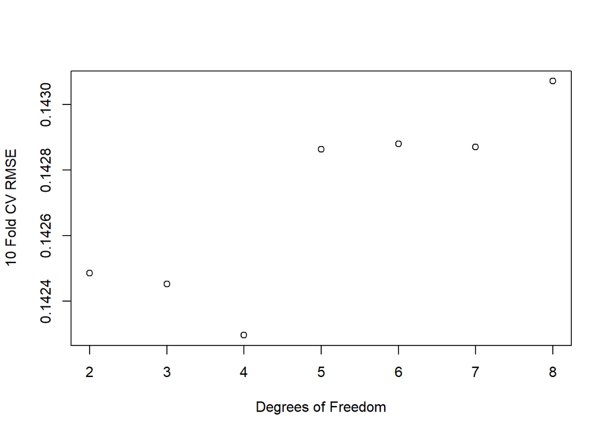

```r
errors <- c(cv.gam.2, cv.gam.3, cv.gam.4, cv.gam.5, cv.gam.6, cv.gam.7,
    cv.gam.8)
df <- 2:8

plot(df, errors, xlab = "Degrees of Freedom", ylab = "10 Fold CV RMSE")
```

So, with more flexibility comes more error. This is likely because the model is overfitting the data with more flexibility.

Moving forward, I will use the model with 4 degrees of freedom, because this model has the lowest CV RMSE.

## 12.3 Estimated Test Error

The estimated test error was already calculated above, and is:

```r
cv.gam.4
```

```
## [1] 0.1422957
```

## 12.4 Interpretation

Here is the final model. Note that I removed the nonparametric term for YrSold, because it turned out it wasn’t significant in the model. I suspect that this was only significant because I included smoothing terms for every quantitative predictor. And, now that I’m only using smoothing terms for a few predictors, it because insignificant.

```r
gam.model <- gam(SalePrice ~ LotFrontage + LotArea + YearRemodAdd + s(XOnestFlrSF,
    4) + XTwondFlrSF + BedroomAbvGr + TotRmsAbvGrd + YrSold + s(totalsf,
    4) + MSZoningCAll + MSZoningRL + StreetGrvl + AlleyGrvl + LotShapeIRThree +
    NeighborhoodBlmngtn + NeighborhoodBrDale + NeighborhoodEdwards + NeighborhoodGilbert +
    NeighborhoodMeadowV + NeighborhoodMitchel + NeighborhoodNoRidge + NeighborhoodNPkVill +
    NeighborhoodOldTown + NeighborhoodSawyer + NeighborhoodSomerst + NeighborhoodStoneBr +
    NeighborhoodSWISU + NeighborhoodTimber + ConditionOneNorm + ConditionOnePosA +
    ConditionOneRRAn + ConditionOneRRNn + ConditionTwoNorm + BldgTypeTwofmCon +
    BldgTypeDuplex + RoofStyleFlat + RoofStyleGable + RoofMatlCompShg +
    RoofMatlTarGrv + RoofMatlWdShake + RoofMatlWdShngl + ExteriorOnestWdSdng +
    ExteriorTwondAsbShng + ExteriorTwondBrkFace + ExteriorTwondCmentBd +
    ExteriorTwondHdBoard + ExteriorTwondPlywood + ExteriorTwondWdSdng +
    ExterCondFa + FoundationBrkTil + FoundationPConc + BsmtCondGd + BsmtExposureAv +
    BsmtExposureGd + BsmtFinTypeOneALQ + BsmtFinTypeOneBLQ + BsmtFinTypeTwoALQ +
    BsmtFinSFTwo + HeatingGasA + HeatingGrav + HeatingQCEx + ElectricalFuseF +
    HalfBath + KitchenAbvGr + KitchenQualFa + FunctionalMajTwo + FunctionalMod +
    FireplaceQuPo + GarageTypeTwoTypes + GarageTypeBasment + GarageTypeBuiltIn +
    GarageTypeDetchd + GarageFinishFin + GarageQualTA + GarageCondFa +
    GarageCondTA + PavedDriveN + EnclosedPorch + ScreenPorch + FenceGdWo +
    SaleTypeCWD + SaleTypeNew + SaleConditionAlloca + StreetPave + LandContourLvl +
    LotConfigInside + LandSlopeSev + BldgTypeTwnhsE + HouseStyleSLvl +
    MasVnrTypeStone + BsmtQualTA + BsmtFinTypeOnenoBasement + CentralAirY +
    FireplaceQuTA + GarageTypenoGarage + GarageQualnoGarage + GarageCondnoGarage +
    FencenoFence, data = gam.train)
```

```r
summary.gam <- summary(gam.model)
summary.gam
```

```
##
## Call: gam(formula = SalePrice ~ LotFrontage + LotArea + YearRemodAdd +
##     s(XOnestFlrSF, 4) + XTwondFlrSF + BedroomAbvGr + TotRmsAbvGrd +
##     YrSold + s(totalsf, 4) + MSZoningCAll + MSZoningRL + StreetGrvl +
##     AlleyGrvl + LotShapeIRThree + NeighborhoodBlmngtn + NeighborhoodBrDale +
##     NeighborhoodEdwards + NeighborhoodGilbert + NeighborhoodMeadowV +
##     NeighborhoodMitchel + NeighborhoodNoRidge + NeighborhoodNPkVill +
##     NeighborhoodOldTown + NeighborhoodSawyer + NeighborhoodSomerst +
##     NeighborhoodStoneBr + NeighborhoodSWISU + NeighborhoodTimber +
##     ConditionOneNorm + ConditionOnePosA + ConditionOneRRAn +
##     ConditionOneRRNn + ConditionTwoNorm + BldgTypeTwofmCon +
##     BldgTypeDuplex + RoofStyleFlat + RoofStyleGable + RoofMatlCompShg +
##     RoofMatlTarGrv + RoofMatlWdShake + RoofMatlWdShngl + ExteriorOnestWdSdng +
##     ExteriorTwondAsbShng + ExteriorTwondBrkFace + ExteriorTwondCmentBd +
##     ExteriorTwondHdBoard + ExteriorTwondPlywood + ExteriorTwondWdSdng +
##     ExterCondFa + FoundationBrkTil + FoundationPConc + BsmtCondGd +
##     BsmtExposureAv + BsmtExposureGd + BsmtFinTypeOneALQ + BsmtFinTypeOneBLQ +
##     BsmtFinTypeTwoALQ + BsmtFinSFTwo + HeatingGasA + HeatingGrav +
##     HeatingQCEx + ElectricalFuseF + HalfBath + KitchenAbvGr +
##     KitchenQualFa + FunctionalMajTwo + FunctionalMod + FireplaceQuPo +
##     GarageTypeTwoTypes + GarageTypeBasment + GarageTypeBuiltIn +
##     GarageTypeDetchd + GarageFinishFin + GarageQualTA + GarageCondFa +
##     GarageCondTA + PavedDriveN + EnclosedPorch + ScreenPorch +
##     FenceGdWo + SaleTypeCWD + SaleTypeNew + SaleConditionAlloca +
##     StreetPave + LandContourLvl + LotConfigInside + LandSlopeSev +
##     BldgTypeTwnhsE + HouseStyleSLvl + MasVnrTypeStone + BsmtQualTA +
##     BsmtFinTypeOnenoBasement + CentralAirY + FireplaceQuTA +
##     GarageTypenoGarage + GarageQualnoGarage + GarageCondnoGarage +
##     FencenoFence, data = gam.train)
## Deviance Residuals:
##       Min        1Q    Median        3Q       Max
## -0.738968 -0.070812  0.005546  0.072357  0.457534
##
## (Dispersion Parameter for gaussian family taken to be 0.0172)
##
##     Null Deviance: 231.9952 on 1453 degrees of freedom
## Residual Deviance: 23.2099 on 1353 degrees of freedom
## AIC: -1685.646
##
## Number of Local Scoring Iterations: NA
```

[output cut: 189 more lines]

```
## LotConfigInside
## LandSlopeSev
## BldgTypeTwnhsE
## HouseStyleSLvl
## MasVnrTypeStone
## BsmtQualTA
## BsmtFinTypeOnenoBasement
## CentralAirY
## FireplaceQuTA
## GarageTypenoGarage
## GarageQualnoGarage
## GarageCondnoGarage
## FencenoFence
## ---
## Signif. codes:  0 '***' 0.001 '**' 0.01 '*' 0.05 '.' 0.1 ' ' 1
```

```r
table(summary.gam$parametric.anova[, 5] < 0.05)
```

```
##
## FALSE  TRUE
##    30    64
```

64 of the predictor’s have a significant p-value in the model for the parametric anova, while 30 do not.

However, I still choose this to be my final model, simply because these predictors were chosen via the best subset selection earlier.